# The dm2200 example

- Show All Code
- Hide All Code
- View Source

Propensity Matching (in several ways) using R

Author

Thomas E. Love, Ph.D.

Published

2025-01-27

# 1 Setup

```r
knitr::opts_chunk$set(comment = NA) # do not remove this

library(janitor) # load other packages as desired
library(naniar)

library(gt)
library(tableone)
library(broom)
library(Epi)
library(survival)
library(Matching)
library(MatchIt)
library(cobalt)
library(lme4)
library(survey)
library(rbounds)

library(easystats)
library(tidyverse) # load tidyverse last

## Note that we will also use the broom.mixed package
## but we won't load it here

theme_set(theme_bw()) # set theme for ggplots
```

## 1.1 The `dm2200` Data Set

I’ve simulated data to match real information we’ve collected over the years at Better Health Partnership on adults who live with diabetes. These data mirror some of the real data collected from electronic health records across the region by Better Health Partnership, but individual values have been permuted across patients, so the results are not applicable to any population. The data I simulated from was a subset of Better Health data that required that the subject fall into exactly one of the two exposure groups we’ll study, that they live in Cuyahoga County, prefer English for health-related communications, and have no missing data on the variables we’ll study.

- The *exposure* we’ll study is called `exposure` and consists of two levels: A and B. I won’t specify the details further on how the exposure is determined, except to say that it is uniquely determinable for each subject.
- We’ll study a binary outcome, specifically whether the subject’s blood pressure is in control, in the sense that both their systolic blood pressure is below 140 mm Hg, *and* their diastolic blood pressure is below 90 mm Hg.
- We’ll also study a continuous outcome, the subject’s body-mass index or `bmi`.

```r
dm2200 <- read_csv("data/dm2200.csv",
                   show_col_types = FALSE) |>
    mutate(across(where(is.character), as_factor)) |>
    mutate(subject = as.character(subject),
           bp_good = as.numeric(sbp < 140 & dbp < 90))

dm2200
```

```
# A tibble: 2,200 × 26
   subject exposure   age race      hisp sex   insur      nincome nhsgrad cleve
   <chr>   <fct>    <dbl> <fct>    <dbl> <fct> <fct>        <dbl>   <dbl> <dbl>
 1 S-0001  A           67 Black_AA     0 F     Medicare     24700      72     1
 2 S-0002  B           56 White        0 F     Commercial   62300      85     0
 3 S-0003  B           41 Black_AA     0 M     Medicare      6500      49     1
 4 S-0004  A           56 Black_AA     0 M     Medicaid     45400      86     0
 5 S-0005  B           69 Black_AA     0 F     Medicare     15400      72     0
 6 S-0006  B           44 Black_AA     0 M     Medicaid     34100      87     0
 7 S-0007  B           47 Black_AA     0 F     Medicaid     13900      42     1
 8 S-0008  B           60 Black_AA     0 M     Medicaid     30800      91     0
 9 S-0009  B           67 Other        1 F     Medicare     47100      90     1
10 S-0010  B           70 Black_AA     0 F     Medicare     20800      69     1
# ℹ 2,190 more rows
# ℹ 16 more variables: height_cm <dbl>, weight_kg <dbl>, bmi <dbl>, a1c <dbl>,
#   sbp <dbl>, dbp <dbl>, ldl <dbl>, visits <dbl>, tobacco <fct>, statin <dbl>,
#   ace_arb <dbl>, betab <dbl>, depr_dx <dbl>, eyeex <dbl>, pneumo <dbl>,
#   bp_good <dbl>
```

## 1.2 Elements of a Codebook

**Variable Descriptions**

**Note**

I used `paste(colnames(dm2200), collapse = " | ")` to help me make this list.

| Variable | Type | Description |
| --- | --- | --- |
| `subject` | character | subject identifier (S-0001 to S-2200) |
| `exposure` | factor (2 levels) | A or B |
| `age` | integer | age in years |
| `race` | factor (4 levels) | White, Black_AA, Asian, Other |
| `hisp` | 1/0 | 1 = Hispanic or Latinx, 0 = not |
| `sex` | F/M | F = Female, M = Male |
| `insur` | factor (4 levels) | Insurance: Medicare, Commercial, Medicaid or Uninsured |
| `nincome` | integer | est. Neighborhood Median Income, in $ |
| `nhsgrad` | integer | est. % of adults in Neighborhood who are High School graduates |
| `cleve` | 1/0 | 1 = Cleveland resident, 0 = resident of suburbs |
| `height_cm` | integer | height in cm |
| `weight_kg` | integer | weight in kg |
| `bmi` | numeric | body mass index (kg/m<sup>2</sup>) |
| `a1c` | numeric | most recent Hemoglobin A1c (in %) |
| `sbp` | numeric | most recent systolic blood pressure (in mm Hg) |
| `dbp` | numeric | most recent diastolic blood pressure (in mm Hg) |
| `bp_good` | 1/0 | 1 if `sbp` < 140 and `dbp` < 90, 0 otherwise |
| `ldl` | numeric | most recent LDL cholesterol (in mg/dl) |
| `visits` | integer | primary care office visits in past year |
| `tobacco` | factor (3 levels) | Tobacco use: Current, Former, Never |
| `statin` | 1/0 | 1 if subject had a statin prescription in the past year |
| `ace_arb` | 1/0 | 1 if subject had an ACE inhibitor or ARB prescription in the past year |
| `betab` | 1/0 | 1 if subject had a beta-blocker prescription in the past year |
| `depr_dx` | 1/0 | 1 if the subject has a depression diagnosis |
| `eyeex` | 1/0 | 1 if the subject has had a retinal eye exam in the past year |
| `pneumo` | 1/0 | 1 if the subject has had a pneumococcal vaccination in the past 10 years |

**data_codebook() (n = 2200)**

```r
data_codebook(dm2200 |> select(-subject))
```

```
select(dm2200, -subject) (2200 rows and 25 variables, 25 shown)

ID | Name      | Type        | Missings |         Values |            N
---+-----------+-------------+----------+----------------+-------------
1  | exposure  | categorical | 0 (0.0%) |              A |  200 ( 9.1%)
   |           |             |          |              B | 2000 (90.9%)
---+-----------+-------------+----------+----------------+-------------
2  | age       | numeric     | 0 (0.0%) |       [25, 75] |         2200
---+-----------+-------------+----------+----------------+-------------
3  | race      | categorical | 0 (0.0%) |       Black_AA | 1231 (56.0%)
   |           |             |          |          White |  867 (39.4%)
   |           |             |          |          Other |   75 ( 3.4%)
   |           |             |          |          Asian |   27 ( 1.2%)
---+-----------+-------------+----------+----------------+-------------
4  | hisp      | numeric     | 0 (0.0%) |              0 | 2092 (95.1%)
   |           |             |          |              1 |  108 ( 4.9%)
---+-----------+-------------+----------+----------------+-------------
5  | sex       | categorical | 0 (0.0%) |              F | 1230 (55.9%)
   |           |             |          |              M |  970 (44.1%)
---+-----------+-------------+----------+----------------+-------------
6  | insur     | categorical | 0 (0.0%) |       Medicare |  950 (43.2%)
   |           |             |          |     Commercial |  517 (23.5%)
   |           |             |          |       Medicaid |  626 (28.5%)
   |           |             |          |      Uninsured |  107 ( 4.9%)
---+-----------+-------------+----------+----------------+-------------
7  | nincome   | numeric     | 0 (0.0%) | [6100, 149300] |         2200
---+-----------+-------------+----------+----------------+-------------
8  | nhsgrad   | numeric     | 0 (0.0%) |       [37, 99] |         2200
---+-----------+-------------+----------+----------------+-------------
9  | cleve     | numeric     | 0 (0.0%) |              0 |  910 (41.4%)
   |           |             |          |              1 | 1290 (58.6%)
---+-----------+-------------+----------+----------------+-------------
10 | height_cm | numeric     | 0 (0.0%) |     [138, 203] |         2200
---+-----------+-------------+----------+----------------+-------------
11 | weight_kg | numeric     | 0 (0.0%) |      [45, 223] |         2200
---+-----------+-------------+----------+----------------+-------------
12 | bmi       | numeric     | 0 (0.0%) |   [16.4, 77.2] |         2200
---+-----------+-------------+----------+----------------+-------------
13 | a1c       | numeric     | 0 (0.0%) |    [4.3, 15.9] |         2200
---+-----------+-------------+----------+----------------+-------------
```

[output cut: 18 more lines]

```
21 | betab     | numeric     | 0 (0.0%) |              0 | 1366 (62.1%)
   |           |             |          |              1 |  834 (37.9%)
---+-----------+-------------+----------+----------------+-------------
22 | depr_dx   | numeric     | 0 (0.0%) |              0 | 1394 (63.4%)
   |           |             |          |              1 |  806 (36.6%)
---+-----------+-------------+----------+----------------+-------------
23 | eyeex     | numeric     | 0 (0.0%) |              0 |  871 (39.6%)
   |           |             |          |              1 | 1329 (60.4%)
---+-----------+-------------+----------+----------------+-------------
24 | pneumo    | numeric     | 0 (0.0%) |              0 |  318 (14.5%)
   |           |             |          |              1 | 1882 (85.5%)
---+-----------+-------------+----------+----------------+-------------
25 | bp_good   | numeric     | 0 (0.0%) |              0 |  652 (29.6%)
   |           |             |          |              1 | 1548 (70.4%)
-----------------------------------------------------------------------
```

**Table 1: Exposure A vs. B**

**Note**

Here is a basic Table 1 comparing the two exposure groups.

```r
t1 <- CreateTableOne(
    vars = c("age", "race", "hisp", "sex", "insur",
             "nincome", "nhsgrad", "cleve", "sbp", "dbp",
             "ldl", "visits", "tobacco", "statin",
             "ace_arb", "betab", "depr_dx", "eyeex",
             "pneumo", "bmi", "bp_good"),
    factorVars = c("hisp", "cleve", "statin",
                   "ace_arb", "betab", "depr_dx",
                   "eyeex", "pneumo", "bp_good"),
    strata = "exposure",
    data = dm2200)

t1
```

```
                     Stratified by exposure
                      A                   B                   p      test
  n                        200                2000
  age (mean (SD))        54.90 (8.55)        58.90 (9.83)     <0.001
  race (%)                                                    <0.001
     Black_AA              166 (83.0)         1065 (53.2)
     White                  31 (15.5)          836 (41.8)
     Other                   1 ( 0.5)           74 ( 3.7)
     Asian                   2 ( 1.0)           25 ( 1.2)
  hisp = 1 (%)               4 ( 2.0)          104 ( 5.2)      0.068
  sex = M (%)              128 (64.0)          842 (42.1)     <0.001
  insur (%)                                                   <0.001
     Medicare               37 (18.5)          913 (45.6)
     Commercial              7 ( 3.5)          510 (25.5)
     Medicaid              125 (62.5)          501 (25.0)
     Uninsured              31 (15.5)           76 ( 3.8)
  nincome (mean (SD)) 26927.50 (11642.18) 37992.55 (20854.20) <0.001
  nhsgrad (mean (SD))    77.74 (11.50)       82.23 (11.35)    <0.001
  cleve = 1 (%)            181 (90.5)         1109 (55.5)     <0.001
  sbp (mean (SD))       135.88 (20.60)      132.44 (16.17)     0.005
  dbp (mean (SD))        82.47 (9.08)        72.41 (11.94)    <0.001
  ldl (mean (SD))        94.34 (38.62)       97.22 (36.66)     0.293
  visits (mean (SD))      4.81 (2.62)         3.69 (1.78)     <0.001
  tobacco (%)                                                 <0.001
     Former                 46 (23.0)          775 (38.8)
     Current               108 (54.0)          445 (22.2)
     Never                  46 (23.0)          780 (39.0)
  statin = 1 (%)           154 (77.0)         1603 (80.2)      0.334
  ace_arb = 1 (%)          160 (80.0)         1531 (76.6)      0.310
  betab = 1 (%)             53 (26.5)          781 (39.1)      0.001
  depr_dx = 1 (%)           53 (26.5)          753 (37.6)      0.002
  eyeex = 1 (%)            104 (52.0)         1225 (61.3)      0.013
  pneumo = 1 (%)           116 (58.0)         1766 (88.3)     <0.001
  bmi (mean (SD))        32.83 (8.22)        35.09 (8.17)     <0.001
  bp_good = 1 (%)          117 (58.5)         1431 (71.6)     <0.001
```

# 2 Propensity for Exposure

We’ll fit a logistic regression model to predict propensity for exposure `A` (as compared to `B`), on the basis of these 18 covariates:

- `age`, `race`, `hisp`, `sex`, `insur`, `nincome`, `nhsgrad`,
- `cleve`, `a1c`, `ldl`, `visits`, `tobacco`, `statin`,
- `ace_arb`, `betab`, `depr_dx`, `eyeex`, `pneumo`

Practically, we might well fit something more complex than a simple model with main effects, but that’s what we’ll limit ourselves to in this setting. Note that we’re not including any direct information on either of our outcomes, or the elements that go into them. In practical work, we might fit different propensity scores for each outcome, but we’re keeping things simple here.

## 2.1 Fitting a Propensity Model

We’ll use the `f.build` tool from the `cobalt` package here.

```r
dm2200 <- dm2200 |>
    mutate(treat = as.logical(exposure == "A"))

covs_1 <- dm2200 |>
    select(age, race, hisp, sex, insur, nincome,
           nhsgrad, cleve, a1c, ldl, visits, tobacco,
           statin, ace_arb, betab, depr_dx, eyeex, pneumo)

prop_model <- glm(f.build("treat", covs_1), data = dm2200,
                  family = binomial)
```

## 2.2 Summarizing the Propensity Model

**Model Parameters**

```r
model_parameters(prop_model, exponentiate = TRUE, ci = 0.95)
```

```
Parameter          | Odds Ratio |       SE |        95% CI |     z |      p
---------------------------------------------------------------------------
(Intercept)        |       0.01 |     0.01 | [0.00,  0.13] | -3.56 | < .001
age                |       1.01 |     0.01 | [0.99,  1.04] |  1.03 | 0.305
race [White]       |       0.32 |     0.08 | [0.19,  0.52] | -4.44 | < .001
race [Other]       |       0.12 |     0.14 | [0.01,  0.79] | -1.86 | 0.063
race [Asian]       |       1.05 |     1.06 | [0.10,  5.97] |  0.05 | 0.962
hisp               |       1.04 |     0.66 | [0.26,  3.26] |  0.06 | 0.949
sex [M]            |       2.30 |     0.44 | [1.59,  3.35] |  4.37 | < .001
insur [Commercial] |       0.38 |     0.17 | [0.15,  0.88] | -2.12 | 0.034
insur [Medicaid]   |       4.31 |     1.11 | [2.62,  7.22] |  5.66 | < .001
insur [Uninsured]  |       9.83 |     3.41 | [4.98, 19.47] |  6.59 | < .001
nincome            |       1.00 | 9.07e-06 | [1.00,  1.00] |  0.25 | 0.803
nhsgrad            |       1.00 | 9.53e-03 | [0.98,  1.02] | -0.42 | 0.677
cleve              |       6.12 |     1.96 | [3.35, 11.80] |  5.65 | < .001
a1c                |       0.96 |     0.05 | [0.88,  1.05] | -0.82 | 0.412
ldl                |       1.00 | 2.58e-03 | [0.99,  1.00] | -1.62 | 0.104
visits             |       1.31 |     0.05 | [1.20,  1.42] |  6.47 | < .001
tobacco [Current]  |       3.11 |     0.71 | [2.00,  4.89] |  5.00 | < .001
tobacco [Never]    |       1.12 |     0.28 | [0.68,  1.83] |  0.44 | 0.657
statin             |       1.01 |     0.23 | [0.65,  1.59] |  0.03 | 0.978
ace arb            |       1.47 |     0.34 | [0.95,  2.32] |  1.68 | 0.093
betab              |       0.77 |     0.16 | [0.51,  1.14] | -1.28 | 0.202
depr dx            |       0.51 |     0.11 | [0.34,  0.77] | -3.20 | 0.001
eyeex              |       0.72 |     0.14 | [0.50,  1.05] | -1.70 | 0.089
pneumo             |       0.20 |     0.04 | [0.13,  0.30] | -7.65 | < .001
```

```
Uncertainty intervals (profile-likelihood) and p-values (two-tailed)
  computed using a Wald z-distribution approximation.
```

**tidy()**

```r
tidy(prop_model, exponentiate = TRUE, conf.int = TRUE, conf.level = 0.95) |>
  select(term, estimate, std.error, conf.low, conf.high, p.value) |>
  gt() |> fmt_number(decimals = 3) |>
  opt_stylize(style = 6, color = "blue")
```

| term | estimate | std.error | conf.low | conf.high | p.value |
| --- | --- | --- | --- | --- | --- |
| (Intercept) | 0.011 | 1.268 | 0.001 | 0.128 | 0.000 |
| age | 1.013 | 0.012 | 0.989 | 1.037 | 0.305 |
| raceWhite | 0.323 | 0.255 | 0.193 | 0.524 | 0.000 |
| raceOther | 0.119 | 1.143 | 0.006 | 0.788 | 0.063 |
| raceAsian | 1.049 | 1.011 | 0.105 | 5.972 | 0.962 |
| hisp | 1.041 | 0.633 | 0.260 | 3.263 | 0.949 |
| sexM | 2.296 | 0.190 | 1.586 | 3.346 | 0.000 |
| insurCommercial | 0.383 | 0.452 | 0.146 | 0.881 | 0.034 |
| insurMedicaid | 4.312 | 0.258 | 2.622 | 7.223 | 0.000 |
| insurUninsured | 9.831 | 0.347 | 4.985 | 19.467 | 0.000 |
| nincome | 1.000 | 0.000 | 1.000 | 1.000 | 0.803 |
| nhsgrad | 0.996 | 0.010 | 0.978 | 1.015 | 0.677 |
| cleve | 6.121 | 0.320 | 3.347 | 11.802 | 0.000 |
| a1c | 0.962 | 0.047 | 0.877 | 1.053 | 0.412 |
| ldl | 0.996 | 0.003 | 0.991 | 1.001 | 0.104 |
| visits | 1.307 | 0.041 | 1.205 | 1.418 | 0.000 |
| tobaccoCurrent | 3.108 | 0.227 | 2.004 | 4.886 | 0.000 |
| tobaccoNever | 1.117 | 0.250 | 0.684 | 1.826 | 0.657 |
| statin | 1.006 | 0.228 | 0.648 | 1.586 | 0.978 |
| ace_arb | 1.468 | 0.229 | 0.946 | 2.325 | 0.093 |
| betab | 0.771 | 0.204 | 0.514 | 1.145 | 0.202 |
| depr_dx | 0.515 | 0.208 | 0.340 | 0.769 | 0.001 |
| eyeex | 0.723 | 0.191 | 0.497 | 1.051 | 0.089 |
| pneumo | 0.200 | 0.211 | 0.132 | 0.301 | 0.000 |

**glance()**

```r
glance(prop_model) |> gt()
```

| null.deviance | df.null | logLik | AIC | BIC | deviance | df.residual | nobs |
| --- | --- | --- | --- | --- | --- | --- | --- |
| 1340.399 | 2199 | -415.85 | 879.7 | 1016.409 | 831.7 | 2176 | 2200 |

**Model Performance**

```r
model_performance(prop_model)
```

```
# Indices of model performance

AIC     |    AICc |      BIC | Tjur's R2 |  RMSE | Sigma | Log_loss | Score_log
-------------------------------------------------------------------------------
879.700 | 880.252 | 1016.409 |     0.329 | 0.237 | 1.000 |    0.189 |      -Inf

AIC     | Score_spherical |   PCP
---------------------------------
879.700 |           0.012 | 0.889
```

## 2.3 Storing the Propensity Scores

```r
dm2200 <- dm2200 |>
    mutate(ps = prop_model$fitted,
           linps = prop_model$linear.predictors)
```

## 2.4 Comparing Propensity Scores

**Comparing the Raw Propensity Scores**

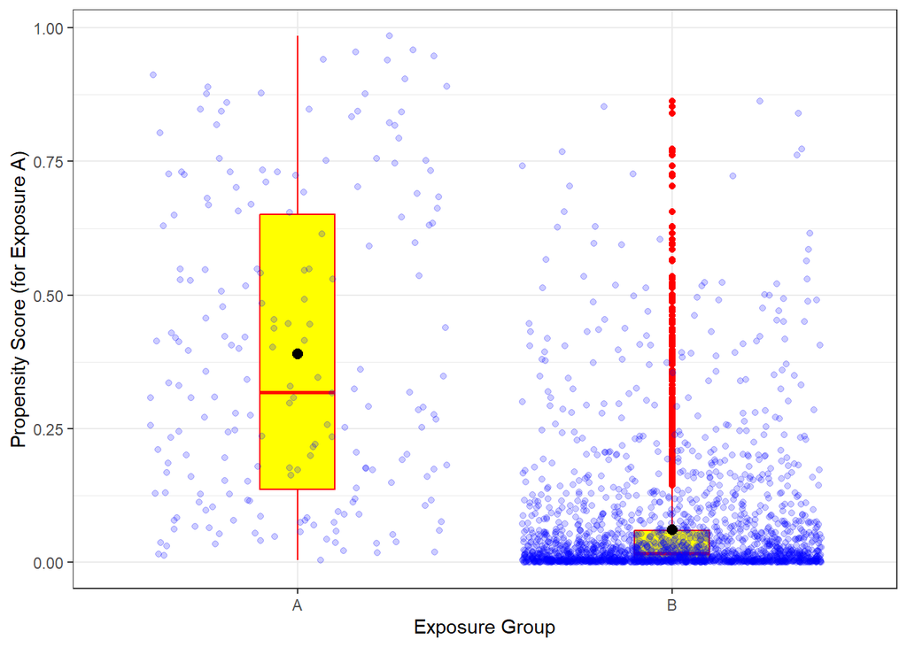

```r
ggplot(dm2200, aes(x = exposure, y = ps)) +
  geom_boxplot(width = 0.2, col = "red", fill = "yellow") +
  geom_jitter(width = 0.4, alpha = 0.2, col = "blue") +
  stat_summary(fun = mean, geom = "point", col = "black", size = 2.5) +
  labs(x = "Exposure Group", y = "Propensity Score (for Exposure A)")
```

**Comparing the Linear Propensity Scores**

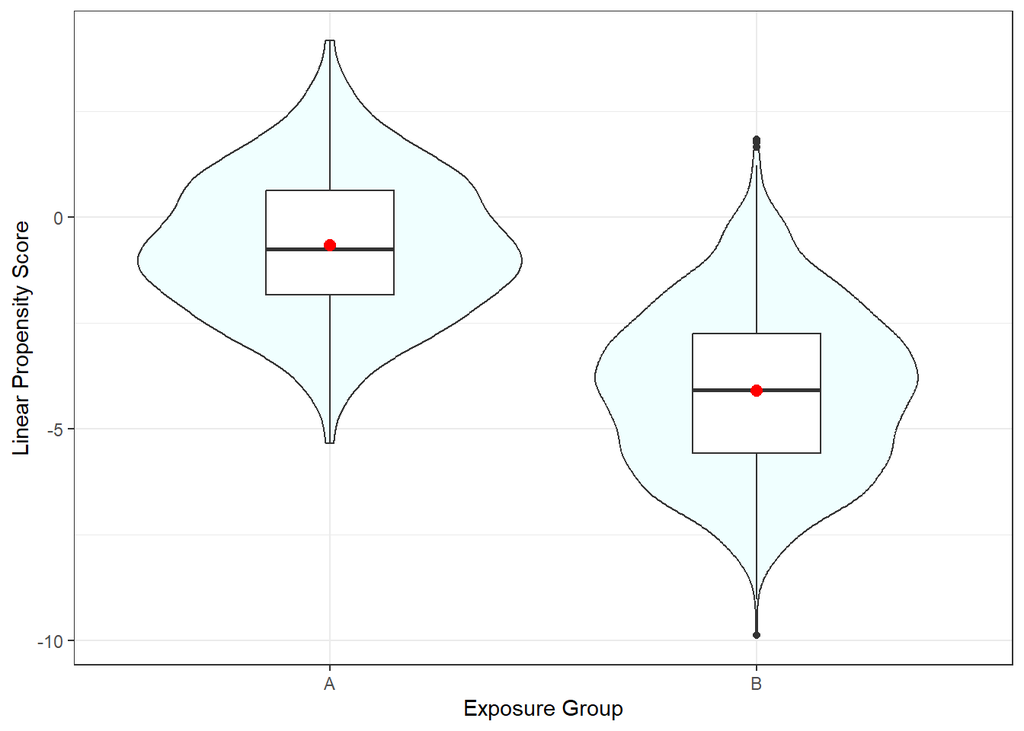

```r
ggplot(dm2200, aes(x = exposure, y = linps)) +
  geom_violin(fill = "azure") +
  geom_boxplot(width = 0.3) +
  stat_summary(fun = mean, geom = "point", col = "red", size = 2.5) +
  labs(x = "Exposure Group", y = "Linear Propensity Score")
```

# 3 `match_1` 1:1 greedy matching without replacement with the `Matching` package

We’re going to match on the linear propensity score, and define our `treat` (treatment) as occurring when `exposure` is A.

```r
match_1 <- Match(Tr = dm2200$treat, X = dm2200$linps,
                 M = 1, replace = FALSE, ties = FALSE,
                 estimand = "ATT")

summary(match_1)
```

```
Estimate...  0
SE.........  0
T-stat.....  NaN
p.val......  NA

Original number of observations..............  2200
Original number of treated obs...............  200
Matched number of observations...............  200
Matched number of observations  (unweighted).  200
```

## 3.1 ATT vs. ATE vs. ATC estimates

Note that in each of the matched samples we build, we’ll focus on ATT estimates (average treated effect on the treated) rather than ATE estimates. This means that in our matching we’re trying to mirror the population represented by the “treated” sample we observed.

- To obtain ATE estimates rather than ATT with the `Match` function from the `Matching` package, use `estimand = "ATE"` in the process of developing the matched sample.
- To obtain ATC estimates (average treatment effect on the controls), use `estimand = "ATC"`.

I encourage the use of ATT estimates in your projects, where possible. I suggest also that you define the “treated” group (the one that the propensity score is estimating) to be the smaller of the two groups you have, to facilitate this approach. If you estimate ATE or ATC instead of ATT, of course, you are answering a different question than what ATT resolves.

## 3.2 Obtaining the Matched Sample

Now, we build a new matched sample data frame in order to do some of the analyses to come. This will contain only the matched subjects.

```r
match1_matches <- factor(rep(match_1$index.treated, 2))
dm2200_matched1 <- cbind(match1_matches,
                         dm2200[c(match_1$index.control,
                                  match_1$index.treated),])
```

Some sanity checks:

```r
dm2200_matched1 |> count(exposure)
```

```
  exposure   n
1        A 200
2        B 200
```

```r
dm2200_matched1 |> head()
```

```
  match1_matches subject exposure age     race hisp sex    insur nincome
1              1  S-0236        B  74 Black_AA    0   M Medicare   28900
2              4  S-1650        B  48 Black_AA    0   M Medicaid   22100
3             17  S-0834        B  61 Black_AA    0   M Medicaid   31500
4             26  S-1232        B  69 Black_AA    0   F Medicare   21700
5             27  S-0678        B  36 Black_AA    0   F Medicaid   16600
6             37  S-1007        B  49 Black_AA    0   M Medicaid   29800
  nhsgrad cleve height_cm weight_kg  bmi  a1c sbp dbp ldl visits tobacco statin
1      75     1       178       105 33.1  8.4 138  79  81      2  Former      1
2      80     1       172       134 45.3  5.1  98  66 121      3   Never      1
3      80     1       183        94 28.1  6.5 127  79 137      3 Current      1
4      77     1       168        65 23.0  5.9 101  70  76      2 Current      1
5      79     1       160        80 31.3 14.5 142  95 157      5 Current      1
6      82     1       170        74 25.6 12.1 138  80 126      3 Current      1
  ace_arb betab depr_dx eyeex pneumo bp_good treat         ps      linps
1       0     0       0     1      1       1 FALSE 0.03787384 -3.2348848
2       1     0       0     0      0       1 FALSE 0.62855155  0.5260079
3       1     0       1     0      1       1 FALSE 0.33963493 -0.6649215
4       1     0       0     1      1       1 FALSE 0.07464006 -2.5175054
5       0     1       0     1      0       0 FALSE 0.40466703 -0.3860563
6       1     0       0     0      1       1 FALSE 0.41799059 -0.3310277
```

## 3.3 Checking Covariate Balance for our 1:1 Greedy Match

### 3.3.1 Using `bal.tab` to obtain a balance table

```r
covs_1plus <- dm2200 |>
    select(age, race, hisp, sex, insur, nincome,
           nhsgrad, cleve, a1c, ldl, visits, tobacco,
           statin, ace_arb, betab, depr_dx, eyeex, pneumo,
           ps, linps)

bal1 <- bal.tab(match_1,
                treat = dm2200$exposure,
                covs = covs_1plus, quick = FALSE,
                data = dm2200, stats = c("m", "v"),
                un = TRUE, disp.v.ratio = TRUE)
bal1
```

```
Balance Measures
                    Type Diff.Un V.Ratio.Un Diff.Adj V.Ratio.Adj
age              Contin.  0.4076     1.3195  -0.0209      1.3292
race_Black_AA     Binary -0.2975          .  -0.0050           .
race_White        Binary  0.2630          .   0.0100           .
race_Other        Binary  0.0320          .  -0.0050           .
race_Asian        Binary  0.0025          .   0.0000           .
hisp              Binary  0.0320          .  -0.0050           .
sex_M             Binary -0.2190          .  -0.0400           .
insur_Medicare    Binary  0.2715          .   0.0400           .
insur_Commercial  Binary  0.2200          .  -0.0050           .
insur_Medicaid    Binary -0.3745          .  -0.0050           .
insur_Uninsured   Binary -0.1170          .  -0.0300           .
nincome          Contin.  0.5306     3.2086  -0.0270      1.3512
nhsgrad          Contin.  0.3958     0.9727  -0.0405      1.0954
cleve             Binary -0.3505          .   0.0250           .
a1c              Contin. -0.0419     0.8190  -0.0189      1.0321
ldl              Contin.  0.0783     0.9012  -0.0038      0.9641
visits           Contin. -0.6304     0.4602  -0.3063      0.7620
tobacco_Former    Binary  0.1575          .   0.0350           .
tobacco_Current   Binary -0.3175          .  -0.0100           .
tobacco_Never     Binary  0.1600          .  -0.0250           .
statin            Binary  0.0315          .  -0.0350           .
ace_arb           Binary -0.0345          .  -0.0450           .
betab             Binary  0.1255          .   0.0050           .
depr_dx           Binary  0.1115          .   0.0200           .
eyeex             Binary  0.0925          .   0.0650           .
pneumo            Binary  0.3030          .   0.0850           .
ps               Contin. -2.9189     0.1576  -0.7387      0.4791
linps            Contin. -1.7842     1.3395  -0.2127      0.5378

Sample sizes
            A    B
All       200 2000
Matched   200  200
Unmatched   0 1800
```

### 3.3.2 Checking Rubin’s Rules 1 and 2

We’ll build a little table of the Rubin’s Rules (1 and 2) before and after our `match_1` is applied.

```r
covs_for_rubin <- dm2200 |>
    select(linps)

rubin_m1 <- bal.tab(match_1,
                treat = dm2200$treat,
                covs = covs_for_rubin,
                data = dm2200, stats = c("m", "v"),
                un = TRUE, disp.v.ratio = TRUE)[1]

rubin_report_m1 <- tibble(
    status = c("Rule1", "Rule2"),
    Unmatched = c(rubin_m1$Balance$Diff.Un,
                  rubin_m1$Balance$V.Ratio.Un),
    Matched = c(rubin_m1$Balance$Diff.Adj,
               rubin_m1$Balance$V.Ratio.Adj))

rubin_report_m1 |>
  gt() |> fmt_number(decimals = 3) |>
  opt_stylize(style = 2, color = "blue")
```

| status | Unmatched | Matched |
| --- | --- | --- |
| Rule1 | 2.065 | 0.246 |
| Rule2 | 0.747 | 1.859 |

- The Rule 1 results tell us about the standardized differences expressed as proportions, so we’d like to be certain that our results are as close to zero as possible, and definitely below 0.5 in absolute value.
  - Multiply these by 100 to describe them as percentages, adjusting the cutoff to below 50 in absolute value.
  - Here, before matching we have a bias of 206.5005338%, and this is reduced to 24.620512% after 1:1 greedy matching.
- The Rule 2 results tell us about the variance ratio of the linear propensity scores. We want this to be within (0.5, 2) and ideally within (0.8, 1.25).
  - Here, before matching we have a variance ratio of 74.6560482%, and this becomes 185.9473698% after 1:1 greedy matching.

### 3.3.3 Using `bal.plot` from `cobalt`

We can look at any particular variable with this approach, for example, age:

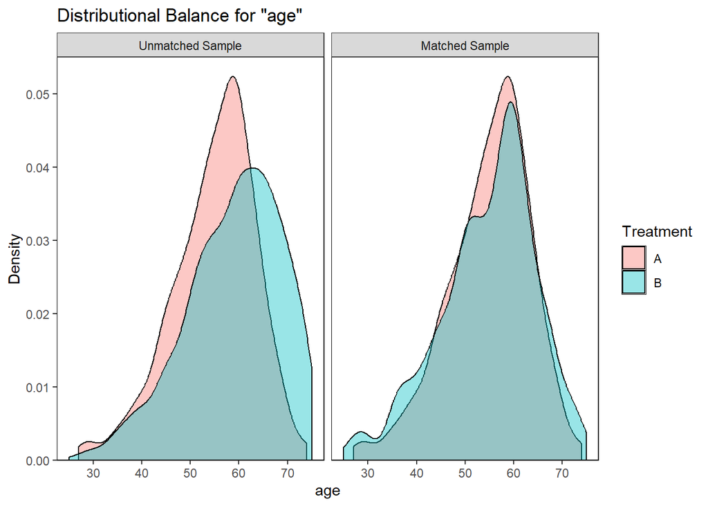

```r
bal.plot(match_1,
         treat = dm2200$exposure,
         covs = covs_1plus,
         var.name = "age",
         which = "both",
         sample.names =
             c("Unmatched Sample", "Matched Sample"))
```

We could also look at the propensity scores in each group, perhaps in mirrored histograms, with …

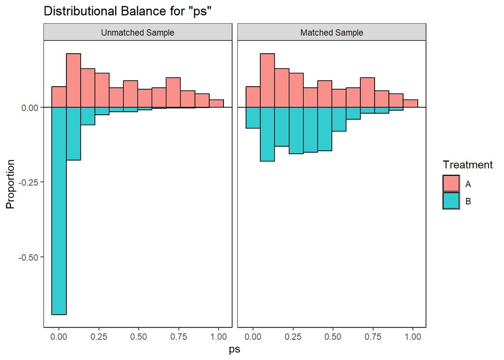

```r
bal.plot(match_1,
         treat = dm2200$exposure,
         covs = covs_1plus,
         var.name = "ps",
         which = "both",
         sample.names =
             c("Unmatched Sample", "Matched Sample"),
         type = "histogram", mirror = TRUE)
```

Can we look at a categorical variable this way?

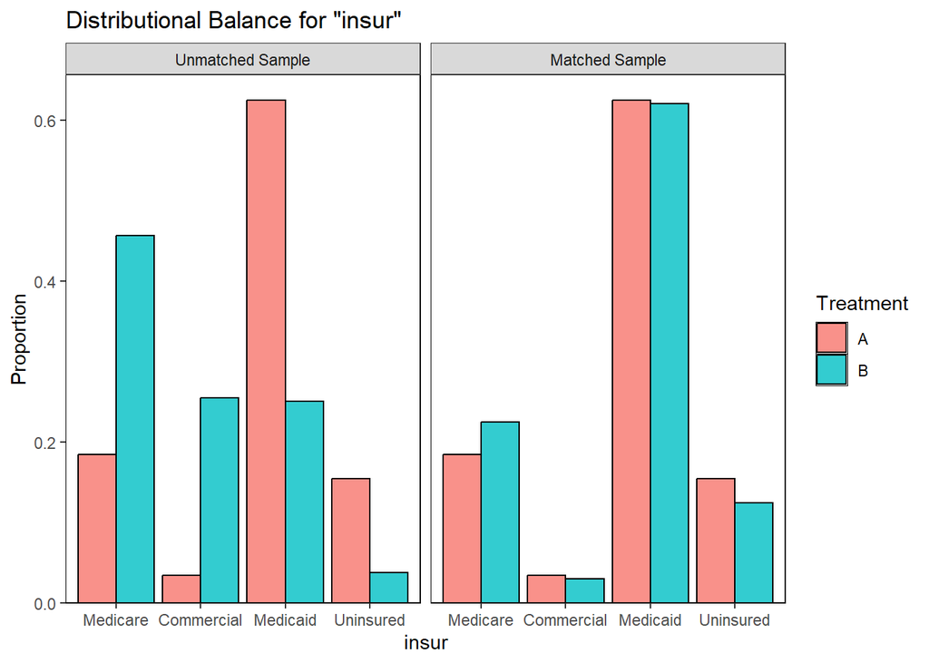

```r
bal.plot(match_1,
         treat = dm2200$exposure,
         covs = covs_1plus,
         var.name = "insur",
         which = "both",
         sample.names =
             c("Unmatched Sample", "Matched Sample"))
```

### 3.3.4 Using `love.plot` to look at Standardized Differences

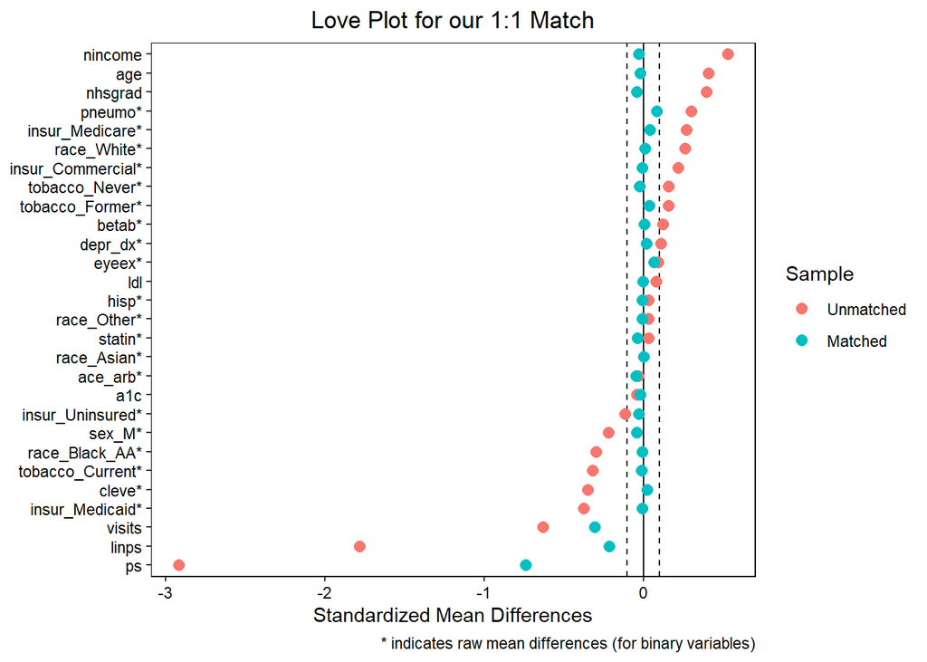

```r
love.plot(bal1,
          threshold = .1, size = 3,
          var.order = "unadjusted",
          stats = "mean.diffs",
          stars = "raw",
          sample.names = c("Unmatched", "Matched"),
          title = "Love Plot for our 1:1 Match") +
    labs(caption = "* indicates raw mean differences (for binary variables)")
```

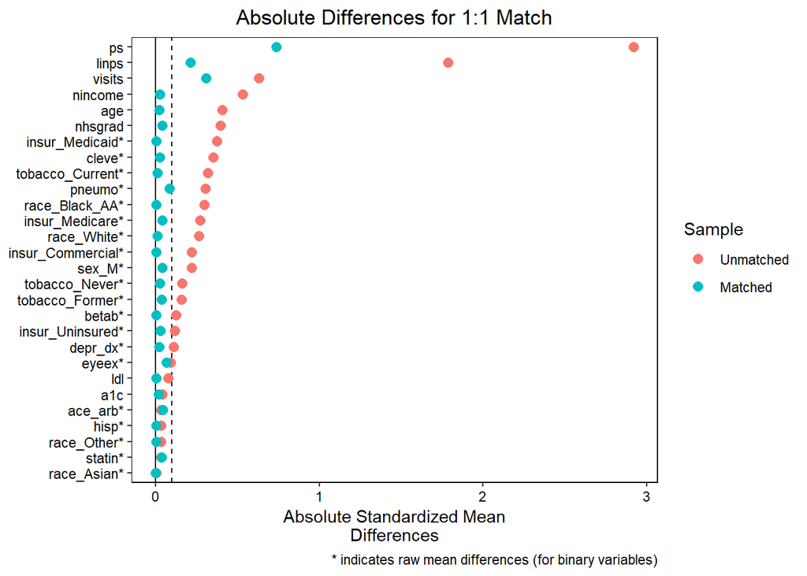

```r
love.plot(bal1,
          threshold = .1, size = 3,
          var.order = "unadjusted",
          stats = "mean.diffs",
          stars = "raw",
          abs = TRUE,
          sample.names = c("Unmatched", "Matched"),
          title = "Absolute Differences for 1:1 Match") +
    labs(caption = "* indicates raw mean differences (for binary variables)")
```

### 3.3.5 Using `love.plot` to look at Variance Ratios

Note that this will only include the variables (and summaries like `ps` and `linps`) that describe quantities. Categorical variables are dropped.

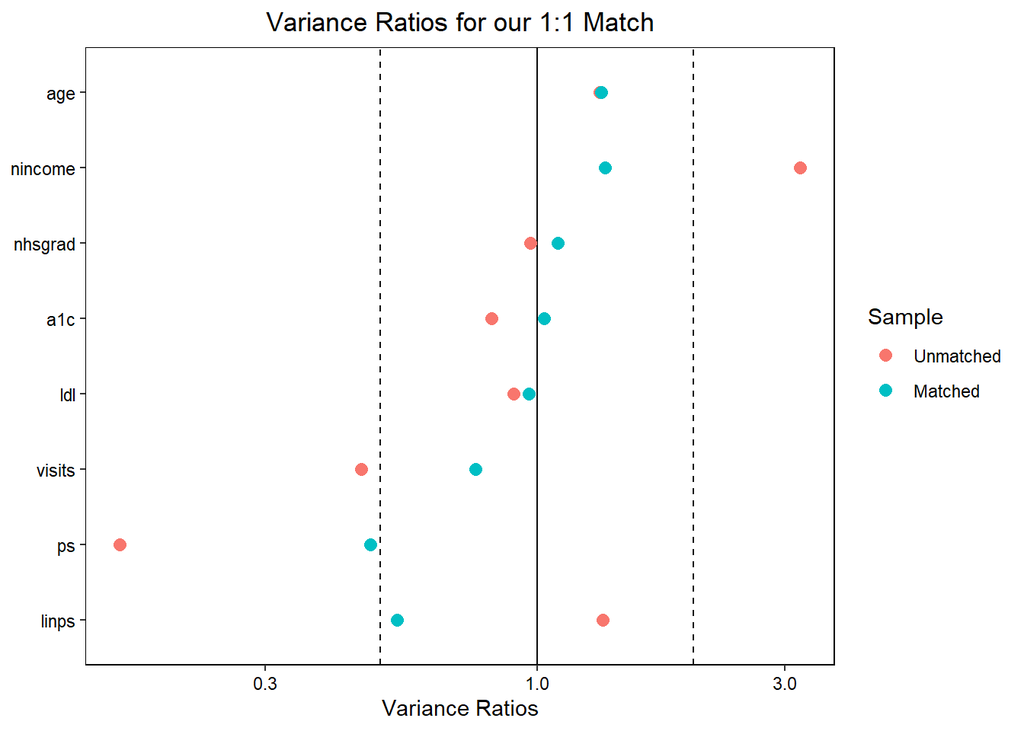

```r
love.plot(bal1,
          threshold = .5, size = 3,
          stats = "variance.ratios",
          sample.names = c("Unmatched", "Matched"),
          title = "Variance Ratios for our 1:1 Match")
```

# 4 `match_2` 1:2 greedy matching without replacement with the `Matching` package

Again, we’ll match on the linear propensity score, and define our `treat` (treatment) as occurring when `exposure` is A. The only difference will be that we’ll allow each subject with exposure A to be matched to exactly two subjects with exposure B.

```r
match_2 <- Match(Tr = dm2200$treat, X = dm2200$linps,
                 M = 2, replace = FALSE, ties = FALSE,
                 estimand = "ATT")

summary(match_2)
```

```
Estimate...  0
SE.........  0
T-stat.....  NaN
p.val......  NA

Original number of observations..............  2200
Original number of treated obs...............  200
Matched number of observations...............  200
Matched number of observations  (unweighted).  400
```

Note that we now have 400 matched exposure “B” subjects in our matched sample.

## 4.1 Obtaining the Matched Sample

As before,

```r
match2_matches <- factor(rep(match_2$index.treated, 2))
dm2200_matched2 <- cbind(match2_matches,
                         dm2200[c(match_2$index.control,
                                  match_2$index.treated),])
```

How many unique subjects are in our matched sample?

```r
n_distinct(dm2200_matched2$subject)
```

```
[1] 600
```

This match repeats each exposure A subject twice, to match up with the 400 exposure B subjects.

```r
dm2200_matched2 |> count(exposure)
```

```
  exposure   n
1        A 400
2        B 400
```

```r
dm2200_matched2 |> count(subject, exposure) |> head()
```

```
  subject exposure n
1  S-0001        A 2
2  S-0004        A 2
3  S-0007        B 1
4  S-0008        B 1
5  S-0014        B 1
6  S-0017        A 2
```

## 4.2 Checking Covariate Balance for our 1:2 Greedy Match

### 4.2.1 Using `bal.tab` to obtain a balance table

```r
covs_2plus <- dm2200 |>
    select(age, race, hisp, sex, insur, nincome,
           nhsgrad, cleve, a1c, ldl, visits, tobacco,
           statin, ace_arb, betab, depr_dx, eyeex, pneumo,
           ps, linps)

bal2 <- bal.tab(match_2,
                treat = dm2200$exposure,
                covs = covs_2plus, quick = FALSE,
                data = dm2200, stats = c("m", "v"),
                un = TRUE, disp.v.ratio = TRUE)
bal2
```

```
Balance Measures
                    Type Diff.Un V.Ratio.Un Diff.Adj V.Ratio.Adj
age              Contin.  0.4076     1.3195   0.0804      1.2519
race_Black_AA     Binary -0.2975          .  -0.0175           .
race_White        Binary  0.2630          .   0.0175           .
race_Other        Binary  0.0320          .  -0.0025           .
race_Asian        Binary  0.0025          .   0.0025           .
hisp              Binary  0.0320          .   0.0025           .
sex_M             Binary -0.2190          .  -0.0750           .
insur_Medicare    Binary  0.2715          .   0.0925           .
insur_Commercial  Binary  0.2200          .  -0.0050           .
insur_Medicaid    Binary -0.3745          .  -0.0400           .
insur_Uninsured   Binary -0.1170          .  -0.0475           .
nincome          Contin.  0.5306     3.2086  -0.0002      1.4755
nhsgrad          Contin.  0.3958     0.9727   0.0170      1.0717
cleve             Binary -0.3505          .  -0.0175           .
a1c              Contin. -0.0419     0.8190  -0.0307      0.8214
ldl              Contin.  0.0783     0.9012   0.0126      0.9109
visits           Contin. -0.6304     0.4602  -0.3204      0.7619
tobacco_Former    Binary  0.1575          .   0.0600           .
tobacco_Current   Binary -0.3175          .  -0.1025           .
tobacco_Never     Binary  0.1600          .   0.0425           .
statin            Binary  0.0315          .   0.0175           .
ace_arb           Binary -0.0345          .  -0.0150           .
betab             Binary  0.1255          .   0.0300           .
depr_dx           Binary  0.1115          .   0.0525           .
eyeex             Binary  0.0925          .   0.0425           .
pneumo            Binary  0.3030          .   0.1525           .
ps               Contin. -2.9189     0.1576  -1.4656      0.3428
linps            Contin. -1.7842     1.3395  -0.4322      0.4092

Sample sizes
            A    B
All       200 2000
Matched   200  400
Unmatched   0 1600
```

### 4.2.2 Checking Rubin’s Rules 1 and 2

We’ll build a little table of the Rubin’s Rules (1 and 2) before and after our 1:2 greedy `match_2` is applied, and compare these to the results we found in `match_1` (the 1:1 match).

```r
covs_for_rubin <- dm2200 |>
    select(linps)

rubin_m2 <- bal.tab(match_2,
                treat = dm2200$treat,
                covs = covs_for_rubin,
                data = dm2200, stats = c("m", "v"),
                un = TRUE, disp.v.ratio = TRUE)[1]

rubin_report_m12 <- tibble(
    status = c("Rule1", "Rule2"),
    Unmatched = c(rubin_m2$Balance$Diff.Un,
                  rubin_m2$Balance$V.Ratio.Un),
    Match1 = c(rubin_m1$Balance$Diff.Adj,
               rubin_m1$Balance$V.Ratio.Adj),
    Match2 = c(rubin_m2$Balance$Diff.Adj,
               rubin_m2$Balance$V.Ratio.Adj))

rubin_report_m12 |>
  gt() |> fmt_number(decimals = 3) |>
  opt_stylize(style = 2, color = "blue")
```

| status | Unmatched | Match1 | Match2 |
| --- | --- | --- | --- |
| Rule1 | 2.065 | 0.246 | 0.500 |
| Rule2 | 0.747 | 1.859 | 2.444 |

- Again, we’d like to see Rule 1 as close to zero as possible, and definitely below 0.5 in absolute value. Unsurprisingly, when we have to match *two* exposure B subjects to each exposure A subject, we don’t get matches that are as close.
- The Rule 2 results tell us about the variance ratio of the linear propensity scores. We want this to be within (0.5, 2) and ideally within (0.8, 1.25). Again, here the results are a bit disappointing in comparison to what we saw in our 1:1 match.

### 4.2.3 Using `bal.plot` from `cobalt`

Looking at the propensity scores in each group, perhaps in mirrored histograms, we have …

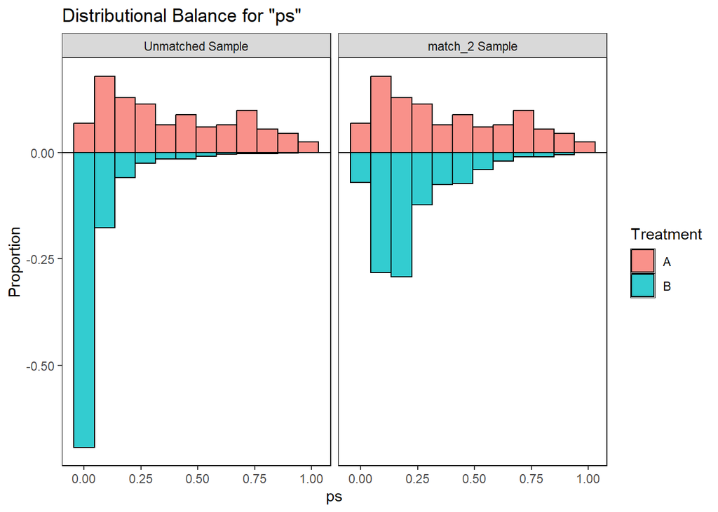

```r
bal.plot(match_2,
         treat = dm2200$exposure,
         covs = covs_2plus,
         var.name = "ps",
         which = "both",
         sample.names =
             c("Unmatched Sample", "match_2 Sample"),
         type = "histogram", mirror = TRUE)
```

### 4.2.4 Using `love.plot` to look at Standardized Differences

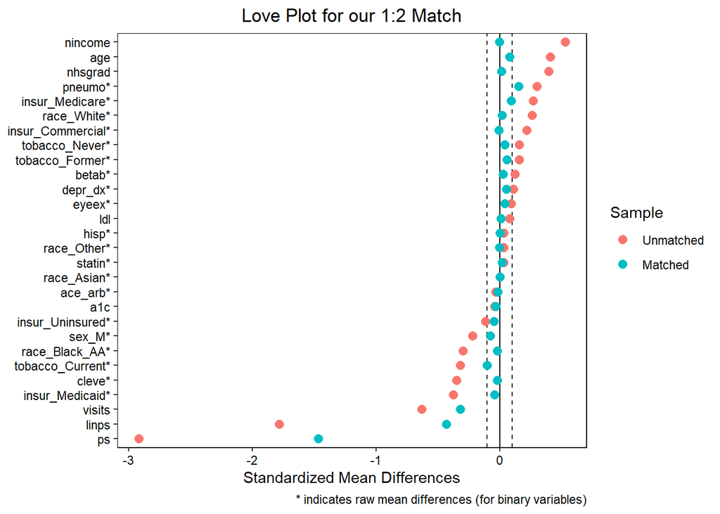

```r
love.plot(bal2,
          threshold = .1, size = 3,
          var.order = "unadjusted",
          stats = "mean.diffs",
          stars = "raw",
          sample.names = c("Unmatched", "Matched"),
          title = "Love Plot for our 1:2 Match") +
    labs(caption = "* indicates raw mean differences (for binary variables)")
```

### 4.2.5 Using `love.plot` to look at Variance Ratios

Again, the categorical variables are dropped.

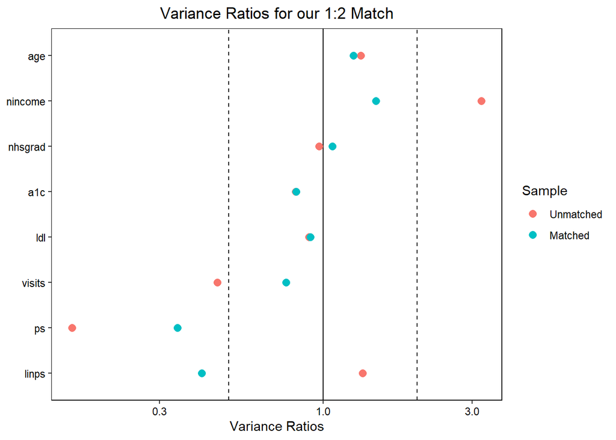

```r
love.plot(bal2,
          threshold = .5, size = 3,
          stats = "variance.ratios",
          sample.names = c("Unmatched", "Matched"),
          title = "Variance Ratios for our 1:2 Match")
```

# 5 `match_3` 1:3 matching, with replacement with the `Matching` package

Again, we’ll match on the linear propensity score, and define our `treat` (treatment) as occurring when `exposure` is A. But now, we’ll match *with* replacement (which means that multiple subject with exposure A can be matched to the same subject with exposure B) and we’ll also match each subject with exposure A to be matched to exactly three subjects with exposure B.

```r
match_3 <- Match(Tr = dm2200$treat, X = dm2200$linps,
                 M = 3, replace = TRUE, ties = FALSE,
                 estimand = "ATT")

summary(match_3)
```

```
Estimate...  0
SE.........  0
T-stat.....  NaN
p.val......  NA

Original number of observations..............  2200
Original number of treated obs...............  200
Matched number of observations...............  200
Matched number of observations  (unweighted).  600
```

Note that we now have 600 matched exposure “B” subjects in our matched sample.

## 5.1 Obtaining the Matched Sample

As before,

```r
match3_matches <- factor(rep(match_3$index.treated, 2))
dm2200_matched3 <- cbind(match3_matches,
                         dm2200[c(match_3$index.control,
                                  match_3$index.treated),])
```

If this was being done without replacement, this would repeat each exposure A subject three times, to match up with the 600 exposure B subjects. But here, we have a different result.

How many unique subjects are in our matched sample?

```r
n_distinct(dm2200_matched3$subject)
```

```
[1] 504
```

How many of those are in Exposure A?

```r
temp <- dm2200_matched3 |> filter(exposure == "A")
n_distinct(temp$subject)
```

```
[1] 200
```

How many of those are in Exposure B?

```r
temp <- dm2200_matched3 |> filter(exposure == "B")
n_distinct(temp$subject)
```

```
[1] 304
```

Among those exposure A subjects, how many times were they used in the matches?

```r
dm2200_matched3 |> filter(exposure == "A") |>
    count(subject) |>
    tabyl(n)
```

```
 n n_n percent
 3 200       1
```

Among those exposure B subjects, how many times were they used in the matches?

```r
dm2200_matched3 |> filter(exposure == "B") |>
    count(subject) |>
    tabyl(n)
```

```
  n n_n     percent
  1 198 0.651315789
  2  62 0.203947368
  3  19 0.062500000
  4   7 0.023026316
  5   4 0.013157895
  6   2 0.006578947
  7   1 0.003289474
  8   1 0.003289474
  9   2 0.006578947
 10   2 0.006578947
 13   2 0.006578947
 15   1 0.003289474
 20   1 0.003289474
 23   1 0.003289474
 24   1 0.003289474
```

## 5.2 Checking Covariate Balance for our 1:3 Match

### 5.2.1 Using `bal.tab` to obtain a balance table

```r
covs_3plus <- dm2200 |>
    select(age, race, hisp, sex, insur, nincome,
           nhsgrad, cleve, a1c, ldl, visits, tobacco,
           statin, ace_arb, betab, depr_dx, eyeex, pneumo,
           ps, linps)

bal3 <- bal.tab(match_3,
                treat = dm2200$exposure,
                covs = covs_3plus, quick = FALSE,
                data = dm2200, stats = c("m", "v"),
                un = TRUE, disp.v.ratio = TRUE)
bal3
```

```
Balance Measures
                    Type Diff.Un V.Ratio.Un Diff.Adj V.Ratio.Adj
age              Contin.  0.4076     1.3195  -0.0845      1.2582
race_Black_AA     Binary -0.2975          .   0.0300           .
race_White        Binary  0.2630          .  -0.0250           .
race_Other        Binary  0.0320          .  -0.0033           .
race_Asian        Binary  0.0025          .  -0.0017           .
hisp              Binary  0.0320          .  -0.0083           .
sex_M             Binary -0.2190          .   0.0133           .
insur_Medicare    Binary  0.2715          .   0.0100           .
insur_Commercial  Binary  0.2200          .  -0.0033           .
insur_Medicaid    Binary -0.3745          .  -0.0283           .
insur_Uninsured   Binary -0.1170          .   0.0217           .
nincome          Contin.  0.5306     3.2086   0.0254      1.3567
nhsgrad          Contin.  0.3958     0.9727  -0.0179      0.8844
cleve             Binary -0.3505          .  -0.0033           .
a1c              Contin. -0.0419     0.8190  -0.0539      1.0273
ldl              Contin.  0.0783     0.9012   0.1121      1.0653
visits           Contin. -0.6304     0.4602  -0.0646      0.8624
tobacco_Former    Binary  0.1575          .   0.0450           .
tobacco_Current   Binary -0.3175          .  -0.0100           .
tobacco_Never     Binary  0.1600          .  -0.0350           .
statin            Binary  0.0315          .  -0.0150           .
ace_arb           Binary -0.0345          .  -0.0083           .
betab             Binary  0.1255          .  -0.0250           .
depr_dx           Binary  0.1115          .   0.0167           .
eyeex             Binary  0.0925          .   0.0017           .
pneumo            Binary  0.3030          .   0.0167           .
ps               Contin. -2.9189     0.1576  -0.0386      0.9512
linps            Contin. -1.7842     1.3395  -0.0268      0.8894

Sample sizes
                       A       B
All                  200 2000.
Matched (ESS)        200  104.53
Matched (Unweighted) 200  304.
Unmatched              0 1696.
```

### 5.2.2 Checking Rubin’s Rules 1 and 2

```r
covs_for_rubin <- dm2200 |>
    select(linps)

rubin_m3 <- bal.tab(match_3,
                treat = dm2200$treat,
                covs = covs_for_rubin,
                data = dm2200, stats = c("m", "v"),
                un = TRUE, disp.v.ratio = TRUE)[1]

rubin_report_m123 <- tibble(
    status = c("Rule1", "Rule2"),
    Unmatched = c(rubin_m2$Balance$Diff.Un,
                  rubin_m2$Balance$V.Ratio.Un),
    Match1 = c(rubin_m1$Balance$Diff.Adj,
               rubin_m1$Balance$V.Ratio.Adj),
    Match2 = c(rubin_m2$Balance$Diff.Adj,
               rubin_m2$Balance$V.Ratio.Adj),
    Match3 = c(rubin_m3$Balance$Diff.Adj,
               rubin_m3$Balance$V.Ratio.Adj))


rubin_report_m123 |>
  gt() |> fmt_number(decimals = 3) |>
  opt_stylize(style = 2, color = "blue")
```

| status | Unmatched | Match1 | Match2 | Match3 |
| --- | --- | --- | --- | --- |
| Rule1 | 2.065 | 0.246 | 0.500 | 0.031 |
| Rule2 | 0.747 | 1.859 | 2.444 | 1.124 |

- Again, we’d like to see Rule 1 results as close to zero as possible, and definitely below 0.5 in absolute value.
- In Rule 2, we want the variance ratio of the linear propensity scores to be within (0.5, 2) and ideally within (0.8, 1.25).
- It appears that (in these data) allowing the same exposure B subject to be used for multiple matches (matching with replacement) more than makes up for the fact that matching 3 exposure B’s for each exposure A (1:3 matching) is a tougher job than pair (1:1) matching, as seen in the results for Rubin’s Rule 1 and Rule 2.

### 5.2.3 Using `bal.plot` from `cobalt`

Looking at the propensity scores in each group, perhaps in mirrored histograms, we have …

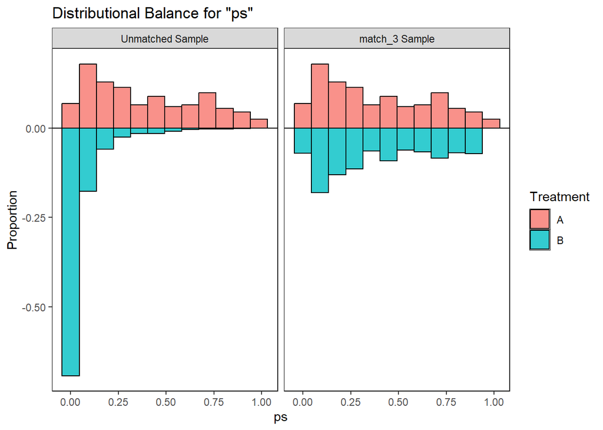

```r
bal.plot(match_3,
         treat = dm2200$exposure,
         covs = covs_3plus,
         var.name = "ps",
         which = "both",
         sample.names =
             c("Unmatched Sample", "match_3 Sample"),
         type = "histogram", mirror = TRUE)
```

### 5.2.4 Using `love.plot` to look at Standardized Differences

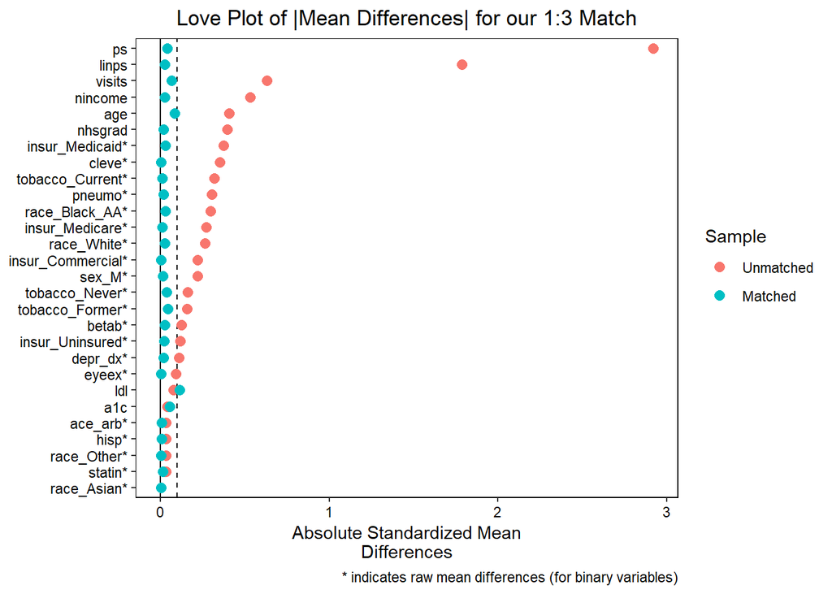

```r
love.plot(bal3,
          threshold = .1, size = 3,
          var.order = "unadjusted",
          stats = "mean.diffs",
          stars = "raw",
          abs = TRUE,
          sample.names = c("Unmatched", "Matched"),
          title = "Love Plot of |Mean Differences| for our 1:3 Match") +
    labs(caption = "* indicates raw mean differences (for binary variables)")
```

### 5.2.5 Using `love.plot` to look at Variance Ratios

Again, the categorical variables are dropped.

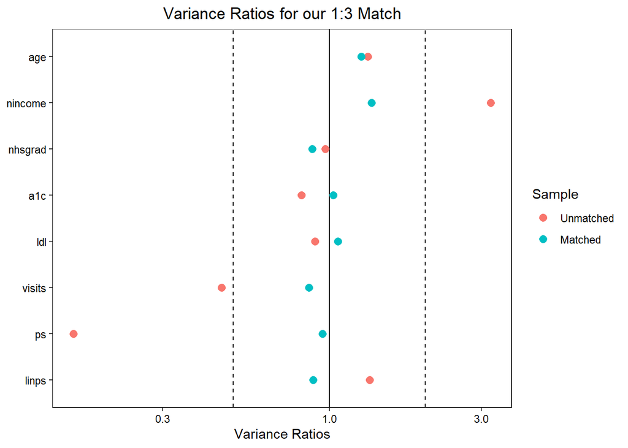

```r
love.plot(bal3,
          threshold = .5, size = 3,
          stats = "variance.ratios",
          sample.names = c("Unmatched", "Matched"),
          title = "Variance Ratios for our 1:3 Match")
```

# 6 `match_4` Caliper Matching (1:1 without replacement) with the `Matching` package

The `Match` function in the `Matching` package allows you to specify a caliper. From the `Matching` help file:

- A caliper is the maximum acceptable distance (on a covariate) which we are willing to accept in any match. Observations for which we cannot find a match within the caliper are dropped.Dropping observations generally changes the quantity being estimated.
- The caliper is interpreted to be in standardized units. For example, caliper=.25 means that all matches not equal to or within .25 standard deviations of each covariate in X are dropped, and not matched.
  - If a scalar caliper is provided to the `caliper` setting in the `Match` function, this caliper is used for all covariates in X.
  - If a vector of calipers is provided, a caliper value should be provided for each covariate in X.

We’ll again perform a 1:1 match without replacement, but now we’ll do so while only accepting matches where the linear propensity score of each match is within 0.2 standard deviations of the linear PS.

```r
match_4 <- Match(Tr = dm2200$treat, X = dm2200$linps,
                 M = 1, replace = FALSE, ties = FALSE,
                 caliper = 0.2, estimand = "ATT")

summary(match_4)
```

```
Estimate...  0
SE.........  0
T-stat.....  NaN
p.val......  NA

Original number of observations..............  2200
Original number of treated obs...............  200
Matched number of observations...............  162
Matched number of observations  (unweighted).  162

Caliper (SDs)........................................   0.2
Number of obs dropped by 'exact' or 'caliper'  38
```

## 6.1 Obtaining the Matched Sample

As before,

```r
match4_matches <- factor(rep(match_4$index.treated, 2))
dm2200_matched4 <- cbind(match4_matches,
                         dm2200[c(match_4$index.control,
                                  match_4$index.treated),])
```

How many unique subjects are in our matched sample?

```r
n_distinct(dm2200_matched4$subject)
```

```
[1] 324
```

This match includes 162 pairs so 324 subjects, since we’ve done matching without replacement.

```r
dm2200_matched4 |> count(exposure)
```

```
  exposure   n
1        A 162
2        B 162
```

## 6.2 Checking Covariate Balance for our 1:1 Caliper Match

### 6.2.1 Using `bal.tab` to obtain a balance table

```r
covs_4plus <- dm2200 |>
    select(age, race, hisp, sex, insur, nincome,
           nhsgrad, cleve, a1c, ldl, visits, tobacco,
           statin, ace_arb, betab, depr_dx, eyeex, pneumo,
           ps, linps)

bal4 <- bal.tab(match_4,
                treat = dm2200$exposure,
                covs = covs_4plus, quick = FALSE,
                data = dm2200, stats = c("m", "v"),
                un = TRUE, disp.v.ratio = TRUE)
bal4
```

```
Balance Measures
                    Type Diff.Un V.Ratio.Un Diff.Adj V.Ratio.Adj
age              Contin.  0.4076     1.3195  -0.0069      1.1267
race_Black_AA     Binary -0.2975          .  -0.0062           .
race_White        Binary  0.2630          .   0.0123           .
race_Other        Binary  0.0320          .   0.0000           .
race_Asian        Binary  0.0025          .  -0.0062           .
hisp              Binary  0.0320          .  -0.0062           .
sex_M             Binary -0.2190          .   0.0000           .
insur_Medicare    Binary  0.2715          .   0.0247           .
insur_Commercial  Binary  0.2200          .  -0.0185           .
insur_Medicaid    Binary -0.3745          .  -0.0062           .
insur_Uninsured   Binary -0.1170          .   0.0000           .
nincome          Contin.  0.5306     3.2086  -0.0071      1.5352
nhsgrad          Contin.  0.3958     0.9727  -0.0501      1.2527
cleve             Binary -0.3505          .   0.0062           .
a1c              Contin. -0.0419     0.8190  -0.0732      0.8675
ldl              Contin.  0.0783     0.9012   0.0115      0.9169
visits           Contin. -0.6304     0.4602  -0.1353      1.1436
tobacco_Former    Binary  0.1575          .   0.0062           .
tobacco_Current   Binary -0.3175          .   0.0370           .
tobacco_Never     Binary  0.1600          .  -0.0432           .
statin            Binary  0.0315          .   0.0000           .
ace_arb           Binary -0.0345          .  -0.0309           .
betab             Binary  0.1255          .   0.0679           .
depr_dx           Binary  0.1115          .  -0.0432           .
eyeex             Binary  0.0925          .  -0.0123           .
pneumo            Binary  0.3030          .   0.0000           .
ps               Contin. -2.9189     0.1576  -0.0309      0.9599
linps            Contin. -1.7842     1.3395  -0.0073      0.9775

Sample sizes
            A    B
All       200 2000
Matched   162  162
Unmatched   0 1838
Discarded  38    0
```

### 6.2.2 Checking Rubin’s Rules 1 and 2

```r
covs_for_rubin <- dm2200 |>
    select(linps)

rubin_m4 <- bal.tab(match_4,
                treat = dm2200$treat,
                covs = covs_for_rubin,
                data = dm2200, stats = c("m", "v"),
                un = TRUE, disp.v.ratio = TRUE)[1]

rubin_report_m1234 <- tibble(
    status = c("Rule1", "Rule2"),
    Unmatched = c(rubin_m2$Balance$Diff.Un,
                  rubin_m2$Balance$V.Ratio.Un),
    Match1 = c(rubin_m1$Balance$Diff.Adj,
               rubin_m1$Balance$V.Ratio.Adj),
    Match2 = c(rubin_m2$Balance$Diff.Adj,
               rubin_m2$Balance$V.Ratio.Adj),
    Match3 = c(rubin_m3$Balance$Diff.Adj,
               rubin_m3$Balance$V.Ratio.Adj),
    Match4 = c(rubin_m4$Balance$Diff.Adj,
               rubin_m4$Balance$V.Ratio.Adj))

rubin_report_m1234 |> gt() |> fmt_number(decimals = 3) |>
  opt_stylize(style = 2, color = "blue")
```

| status | Unmatched | Match1 | Match2 | Match3 | Match4 |
| --- | --- | --- | --- | --- | --- |
| Rule1 | 2.065 | 0.246 | 0.500 | 0.031 | 0.008 |
| Rule2 | 0.747 | 1.859 | 2.444 | 1.124 | 1.023 |

- This approach produces an exceptionally strong match in terms of balance, with Rubin’s Rule 1 being very close to 0, and Rule 2 being very close to 1.
- Unfortunately, we’ve only done this by dropping the 38 “hardest to match” subjects receiving exposure “A”.

### 6.2.3 Using `bal.plot` from `cobalt`

Looking at the propensity scores in each group, perhaps in mirrored histograms, we have …

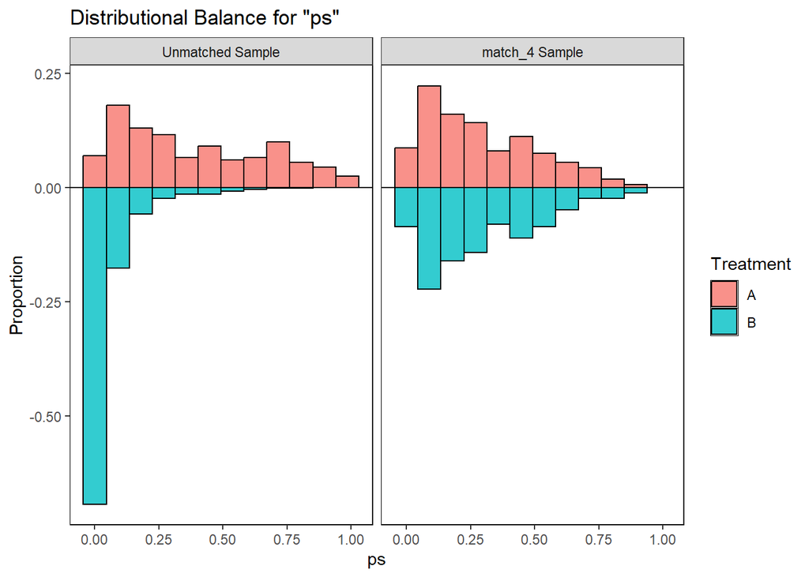

```r
bal.plot(match_4,
         treat = dm2200$exposure,
         covs = covs_4plus,
         var.name = "ps",
         which = "both",
         sample.names =
             c("Unmatched Sample", "match_4 Sample"),
         type = "histogram", mirror = TRUE)
```

### 6.2.4 Using `love.plot` to look at Standardized Differences

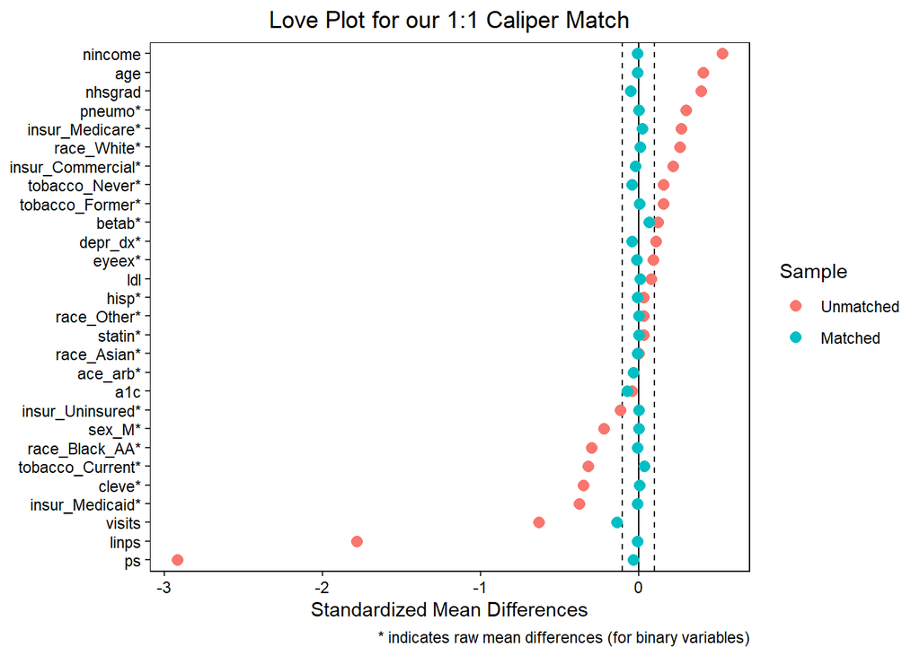

```r
love.plot(bal4,
          threshold = .1, size = 3,
          var.order = "unadjusted",
          stats = "mean.diffs",
          stars = "raw",
          sample.names = c("Unmatched", "Matched"),
          title = "Love Plot for our 1:1 Caliper Match") +
    labs(caption = "* indicates raw mean differences (for binary variables)")
```

### 6.2.5 Using `love.plot` to look at Variance Ratios

Again, the categorical variables are dropped.

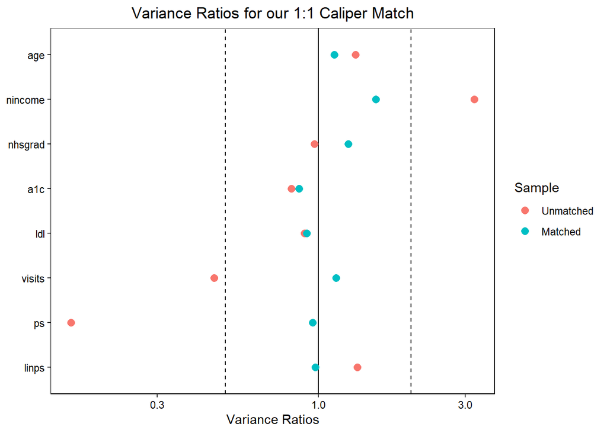

```r
love.plot(bal4,
          threshold = .5, size = 3,
          stats = "variance.ratios",
          sample.names = c("Unmatched", "Matched"),
          title = "Variance Ratios for our 1:1 Caliper Match")
```

# 7 `match_5` 1:1 Nearest Neighbor Matching with `Matchit`

The `MatchIt` package implements the suggestions of Ho, Imai, King, and Stuart (2007) for improving parametric statistical models by pre-processing data with nonparametric matching methods. Read more about `MatchIt` at https://gking.harvard.edu/matchit.

With `MatchIt`, the matching is done using the `matchit(treat ~ X, ...)` function, where `treat` is the vector of treatment assignments and `X` are the covariates to be used in the matching.

We’ll start our exploration of the `MatchIt` approach to developing matches with nearest neighbor matching, which (quoting the `MatchIt` manual…)

> … selects the *r* (default = 1, specified by the `ratio` option) best control matches for each individual in the treated group, using a distance measure specified by the `distance` option (default = logit). Matches are chosen for each treated unit one at a time, with the order specified by the `m.order` command (default=largest to smallest). At each matching step we choose the control unit that is not yet matched but is closest to the treated unit on the distance measure.

The full syntax (with default choices indicated) is

```
matchit(formula, data=NULL, discard=0, exact=FALSE,
         replace=FALSE, ratio=1, model="logit",
         reestimate=FALSE, nearest=TRUE, m.order=2,
         caliper=0, calclosest=FALSE, mahvars=NULL,
         subclass=0, sub.by="treat", counter=TRUE,
         full=FALSE, full.options=list(), ...)
```

Here, we’ll match on the linear propensity score (by specifying the `distance` to use the logistic link with the linear propensity score via `"linear.logit"`), and we’ll perform 1:1 nearest neighbor matching without replacement using the default ordering (largest to smallest). Since we’ve already seen that greedy 1:1 matching without replacement doesn’t work well in this setting, we’re not expecting a strong result in terms of balance here, either.

```r
dm2200 <- dm2200 |>
    mutate(treat = as.logical(exposure == "A"))

covs_1 <- dm2200 |>
    select(age, race, hisp, sex, insur, nincome,
           nhsgrad, cleve, a1c, ldl, visits, tobacco,
           statin, ace_arb, betab, depr_dx, eyeex, pneumo)

match_5 <- matchit(f.build("treat", covs_1), data = dm2200,
                   distance = "glm", link = "linear.logit",
                   method = "nearest",
                   ratio = 1, replace = FALSE)

match_5
```

```
A `matchit` object
 - method: 1:1 nearest neighbor matching without replacement
 - distance: Propensity score
             - estimated with logistic regression and linearized
 - number of obs.: 2200 (original), 400 (matched)
 - target estimand: ATT
 - covariates: age, race, hisp, sex, insur, nincome, nhsgrad, cleve, a1c, ldl, visits, tobacco, statin, ace_arb, betab, depr_dx, eyeex, pneumo
```

## 7.1 Obtaining the Matched Sample

There is just one tricky part to doing this in `MatchIt`. The main work can be done with a very simple command.

```r
dm2200_matched5 <- match.data(match_5)
```

This leaves only the job of creating a matching number, for which we have to develop some additional R code.

```r
# Thanks to Robert McDonald at Mayo
# https://lists.gking.harvard.edu/pipermail/matchit/2012-April/000458.html

len <- dim(dm2200)[1]
matchx <- rep(NA,len)
len2 <- length(match_5$match.matrix)
count <- 1
for(i in 1:len2){

    match1 <- match_5$match.matrix[i]
    match2 <- row.names(match_5$match.matrix)[i]

    if(!is.na(match1)){
    matchx[as.numeric(match1)] <- count
    matchx[as.numeric(match2)] <- count
    count <- count+1}

}

dm2200_matched5 <- dm2200_matched5 |>
    mutate(match5_matches =
               matchx[as.numeric
                      (row.names(dm2200_matched5))]) |>
    mutate(match5_matches = factor(match5_matches))
```

How many unique subjects are in our matched sample?

```r
n_distinct(dm2200_matched5$subject)
```

```
[1] 400
```

This match includes 200 pairs so 400 subjects, as we’ve done matching without replacement.

```r
dm2200_matched5 |> count(exposure)
```

```
# A tibble: 2 × 2
  exposure     n
  <fct>    <int>
1 A          200
2 B          200
```

## 7.2 Checking Covariate Balance for our 1:1 Nearest Neighbor Match

### 7.2.1 Default Numerical Balance Summary from `MatchIt`

```r
summary(match_5)
```

```
Call:
matchit(formula = f.build("treat", covs_1), data = dm2200, method = "nearest",
    distance = "glm", link = "linear.logit", replace = FALSE,
    ratio = 1)

Summary of Balance for All Data:
                Means Treated Means Control Std. Mean Diff. Var. Ratio
distance              -0.6577       -4.0979          2.0650     0.7466
age                   54.8950       58.9000         -0.4682     0.7579
raceBlack_AA           0.8300        0.5325          0.7920          .
raceWhite              0.1550        0.4180         -0.7267          .
raceOther              0.0050        0.0370         -0.4537          .
raceAsian              0.0100        0.0125         -0.0251          .
hisp                   0.0200        0.0520         -0.2286          .
sexF                   0.3600        0.5790         -0.4562          .
sexM                   0.6400        0.4210          0.4563          .
insurMedicare          0.1850        0.4565         -0.6992          .
insurCommercial        0.0350        0.2550         -1.1971          .
insurMedicaid          0.6250        0.2505          0.7736          .
insurUninsured         0.1550        0.0380          0.3233          .
nincome            26927.5000    37992.5500         -0.9504     0.3117
nhsgrad               77.7350       82.2260         -0.3904     1.0281
cleve                  0.9050        0.5545          1.1954          .
a1c                    7.7655        7.6868          0.0379     1.2209
ldl                   94.3450       97.2160         -0.0743     1.1096
visits                 4.8100        3.6885          0.4276     2.1732
tobaccoFormer          0.2300        0.3875         -0.3743          .
tobaccoCurrent         0.5400        0.2225          0.6370          .
tobaccoNever           0.2300        0.3900         -0.3802          .
statin                 0.7700        0.8015         -0.0749          .
ace_arb                0.8000        0.7655          0.0863          .
betab                  0.2650        0.3905         -0.2844          .
depr_dx                0.2650        0.3765         -0.2526          .
eyeex                  0.5200        0.6125         -0.1851          .
pneumo                 0.5800        0.8830         -0.6139          .
                eCDF Mean eCDF Max
distance           0.4093   0.6595
age                0.0801   0.2350
raceBlack_AA       0.2975   0.2975
raceWhite          0.2630   0.2630
```

[output cut: 76 more lines]

```
tobaccoCurrent     0.0450    0.045          0.8929
tobaccoNever       0.0100    0.010          0.8079
statin             0.0550    0.055          0.9861
ace_arb            0.0350    0.035          0.8625
betab              0.0450    0.045          0.8950
depr_dx            0.0200    0.020          0.8837
eyeex              0.0100    0.010          0.8807
pneumo             0.0800    0.080          0.8510

Sample Sizes:
          Control Treated
All          2000     200
Matched       200     200
Unmatched    1800       0
Discarded       0       0
```

### 7.2.2 Using `bal.tab` to obtain a balance table

```r
bal5 <- bal.tab(match_5, un = TRUE, disp.v.ratio = TRUE)

bal5
```

```
Balance Measures
                     Type Diff.Un V.Ratio.Un Diff.Adj V.Ratio.Adj
distance         Distance  2.0650     0.7466   0.2462      1.8590
age               Contin. -0.4682     0.7579   0.0754      0.8059
race_Black_AA      Binary  0.2975          .   0.0000           .
race_White         Binary -0.2630          .  -0.0050           .
race_Other         Binary -0.0320          .   0.0050           .
race_Asian         Binary -0.0025          .   0.0000           .
hisp               Binary -0.0320          .   0.0050           .
sex_M              Binary  0.2190          .   0.0400           .
insur_Medicare     Binary -0.2715          .   0.0050           .
insur_Commercial   Binary -0.2200          .  -0.0050           .
insur_Medicaid     Binary  0.3745          .  -0.0200           .
insur_Uninsured    Binary  0.1170          .   0.0200           .
nincome           Contin. -0.9504     0.3117   0.1324      1.1096
nhsgrad           Contin. -0.3904     1.0281   0.0235      1.0794
cleve              Binary  0.3505          .   0.0000           .
a1c               Contin.  0.0379     1.2209  -0.0334      0.9035
ldl               Contin. -0.0743     1.1096  -0.0038      1.0865
visits            Contin.  0.4276     2.1732   0.1792      1.3150
tobacco_Former     Binary -0.1575          .  -0.0350           .
tobacco_Current    Binary  0.3175          .   0.0450           .
tobacco_Never      Binary -0.1600          .  -0.0100           .
statin             Binary -0.0315          .   0.0550           .
ace_arb            Binary  0.0345          .   0.0350           .
betab              Binary -0.1255          .  -0.0450           .
depr_dx            Binary -0.1115          .  -0.0200           .
eyeex              Binary -0.0925          .  -0.0100           .
pneumo             Binary -0.3030          .  -0.0800           .

Sample sizes
          Control Treated
All          2000     200
Matched       200     200
Unmatched    1800       0
```

### 7.2.3 Checking Rubin’s Rules 1 and 2

We’ll build a little table of the Rubin’s Rules (1 and 2) results before and after `match_5` is applied.

```r
rubin_report_m5 <- tibble(
    status = c("Rule1", "Rule2"),
    Unmatched = c(bal5$Balance$Diff.Un[1],
                  bal5$Balance$V.Ratio.Un[1]),
    Match5 = c(bal5$Balance$Diff.Adj[1],
               bal5$Balance$V.Ratio.Adj[1]))

rubin_report_m5 |> gt() |> fmt_number(decimals = 3) |>
  opt_stylize(style = 2, color = "blue")
```

| status | Unmatched | Match5 |
| --- | --- | --- |
| Rule1 | 2.065 | 0.246 |
| Rule2 | 0.747 | 1.859 |

- As we’d expect based on our previous greedy 1:1 match, this isn’t great sufficiently strong balance.

### 7.2.4 Using `bal.plot` from `cobalt`

Looking at the linear propensity scores in each group, in mirrored histograms, we have …

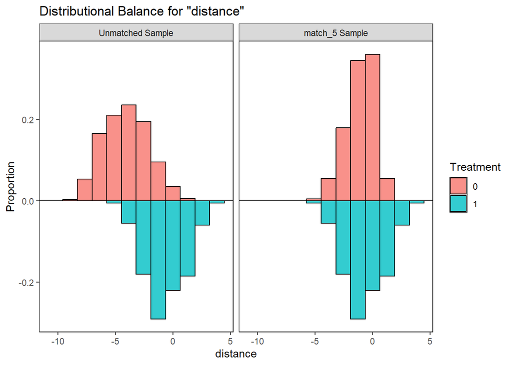

```r
bal.plot(match_5,
         var.name = "distance",
         which = "both",
         sample.names =
             c("Unmatched Sample", "match_5 Sample"),
         type = "histogram", mirror = TRUE)
```

### 7.2.5 Using `love.plot` to look at Standardized Differences

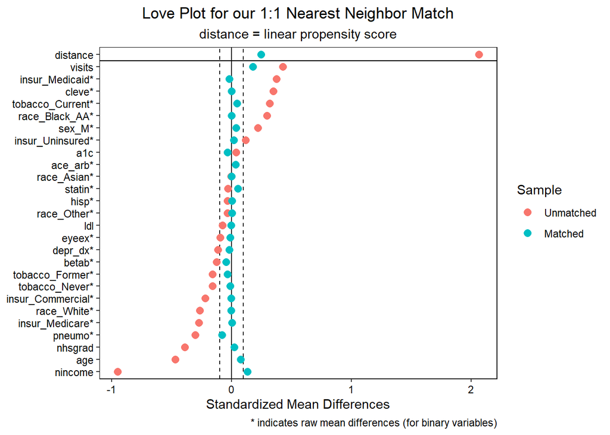

```r
love.plot(bal5,
          threshold = .1, size = 3,
          var.order = "unadjusted",
          stats = "mean.diffs",
          stars = "raw",
          sample.names = c("Unmatched", "Matched"),
          title = "Love Plot for our 1:1 Nearest Neighbor Match") +
    labs(subtitle = "distance = linear propensity score",
         caption = "* indicates raw mean differences (for binary variables)")
```

### 7.2.6 Using `love.plot` to look at Variance Ratios

Again, the categorical variables are dropped.

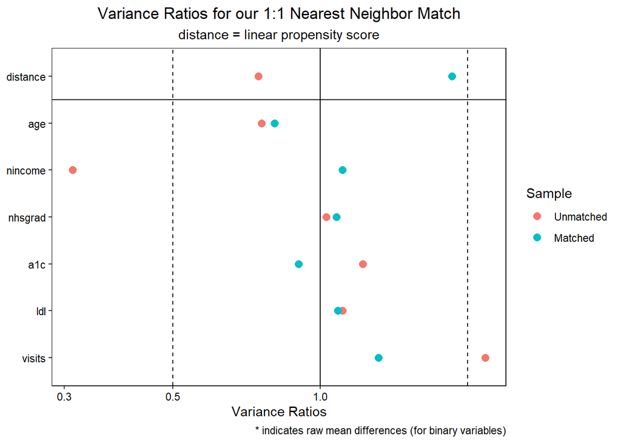

```r
love.plot(bal5,
          threshold = .5, size = 3,
          stats = "variance.ratios",
          sample.names = c("Unmatched", "Matched"),
          title = "Variance Ratios for our 1:1 Nearest Neighbor Match") +
    labs(subtitle = "distance = linear propensity score",
         caption = "* indicates raw mean differences (for binary variables)")
```

# 8 `match_6` 1:1 Nearest Neighbor Caliper Matching with `Matchit`

As in `match_5`, we’ll match on the linear propensity score (by specifying the `distance` to use the logistic link with the linear propensity score via `"linear.logit"`), and we’ll perform 1:1 nearest neighbor matching without replacement using the default ordering (largest to smallest), but we’ll add a some arguments to build a specific kind caliper match. Specifically, we’ll require our matches to be within 0.25 standard deviations of each other on the linear propensity score.

```r
match_6 <- matchit(f.build("treat", covs_1), data = dm2200,
                   distance = "glm", link = "linear.logit",
                   method = "nearest", caliper = 0.25,
                   ratio = 1, replace = FALSE)

match_6
```

```
A `matchit` object
 - method: 1:1 nearest neighbor matching without replacement
 - distance: Propensity score [caliper]

             - estimated with logistic regression and linearized
 - caliper: <distance> (0.537)
 - number of obs.: 2200 (original), 344 (matched)
 - target estimand: ATT
 - covariates: age, race, hisp, sex, insur, nincome, nhsgrad, cleve, a1c, ldl, visits, tobacco, statin, ace_arb, betab, depr_dx, eyeex, pneumo
```

## 8.1 Obtaining the Matched Sample

There is just one tricky part to doing this in `MatchIt`. The main work can be done with a very simple command.

```r
dm2200_matched6 <- match.data(match_6)
```

This leaves only the job of creating a matching number, for which we have to develop some additional R code.

```r
# Thanks to Robert McDonald at Mayo
# https://lists.gking.harvard.edu/pipermail/matchit/2012-April/000458.html

len <- dim(dm2200)[1]
matchx <- rep(NA,len)
len2 <- length(match_6$match.matrix)
count <- 1
for(i in 1:len2){

    match1 <- match_6$match.matrix[i]
    match2 <- row.names(match_6$match.matrix)[i]

    if(!is.na(match1)){
    matchx[as.numeric(match1)] <- count
    matchx[as.numeric(match2)] <- count
    count <- count+1}

}

dm2200_matched6 <- dm2200_matched6 |>
    mutate(match6_matches =
               matchx[as.numeric
                      (row.names(dm2200_matched6))]) |>
    mutate(match6_matches = factor(match6_matches))
```

How many unique subjects are in our matched sample?

```r
n_distinct(dm2200_matched6$subject)
```

```
[1] 344
```

This match includes 172 pairs so 344 subjects, as we’ve done matching without replacement.

```r
dm2200_matched6 |> count(exposure)
```

```
# A tibble: 2 × 2
  exposure     n
  <fct>    <int>
1 A          172
2 B          172
```

## 8.2 Checking Covariate Balance for our 1:1 Nearest Neighbor Caliper Match

### 8.2.1 Using `bal.tab` to obtain a balance table

```r
bal6 <- bal.tab(match_6, un = TRUE, disp.v.ratio = TRUE)

bal6
```

```
Balance Measures
                     Type Diff.Un V.Ratio.Un Diff.Adj V.Ratio.Adj
distance         Distance  2.0650     0.7466   0.0612      1.2154
age               Contin. -0.4682     0.7579   0.0068      0.8700
race_Black_AA      Binary  0.2975          .  -0.0116           .
race_White         Binary -0.2630          .   0.0058           .
race_Other         Binary -0.0320          .   0.0058           .
race_Asian         Binary -0.0025          .   0.0000           .
hisp               Binary -0.0320          .   0.0116           .
sex_M              Binary  0.2190          .   0.0233           .
insur_Medicare     Binary -0.2715          .   0.0000           .
insur_Commercial   Binary -0.2200          .  -0.0058           .
insur_Medicaid     Binary  0.3745          .   0.0000           .
insur_Uninsured    Binary  0.1170          .   0.0058           .
nincome           Contin. -0.9504     0.3117   0.1677      1.1339
nhsgrad           Contin. -0.3904     1.0281   0.1137      0.9119
cleve              Binary  0.3505          .   0.0000           .
a1c               Contin.  0.0379     1.2209  -0.0011      0.9429
ldl               Contin. -0.0743     1.1096  -0.0188      1.1241
visits            Contin.  0.4276     2.1732   0.0887      1.2449
tobacco_Former     Binary -0.1575          .  -0.0174           .
tobacco_Current    Binary  0.3175          .   0.0000           .
tobacco_Never      Binary -0.1600          .   0.0174           .
statin             Binary -0.0315          .   0.0349           .
ace_arb            Binary  0.0345          .   0.0174           .
betab              Binary -0.1255          .  -0.0465           .
depr_dx            Binary -0.1115          .   0.0174           .
eyeex              Binary -0.0925          .  -0.0233           .
pneumo             Binary -0.3030          .   0.0000           .

Sample sizes
          Control Treated
All          2000     200
Matched       172     172
Unmatched    1828      28
```

### 8.2.2 Checking Rubin’s Rules 1 and 2

We’ll build a little table of the Rubin’s Rules (1 and 2) results before and after `match_6` is applied, and compare these to the `match_5` results.

```r
rubin_report_m56 <- tibble(
    status = c("Rule1", "Rule2"),
    Unmatched = c(bal6$Balance$Diff.Un[1],
                  bal6$Balance$V.Ratio.Un[1]),
    Match5 = c(bal5$Balance$Diff.Adj[1],
               bal5$Balance$V.Ratio.Adj[1]),
    Match6 = c(bal6$Balance$Diff.Adj[1],
               bal6$Balance$V.Ratio.Adj[1])
    )

rubin_report_m56 |> gt() |> fmt_number(decimals = 3) |>
  opt_stylize(style = 2, color = "blue")
```

| status | Unmatched | Match5 | Match6 |
| --- | --- | --- | --- |
| Rule1 | 2.065 | 0.246 | 0.061 |
| Rule2 | 0.747 | 1.859 | 1.215 |

- So the caliper appears to help quite a bit to improve the results that we saw in 1:1 nearest neighbor matching without replacement, at the cost of not including 28 of the treated subjects in the match.

### 8.2.3 Using `bal.plot` from `cobalt`

Looking at the linear propensity scores in each group, in mirrored histograms, we have …

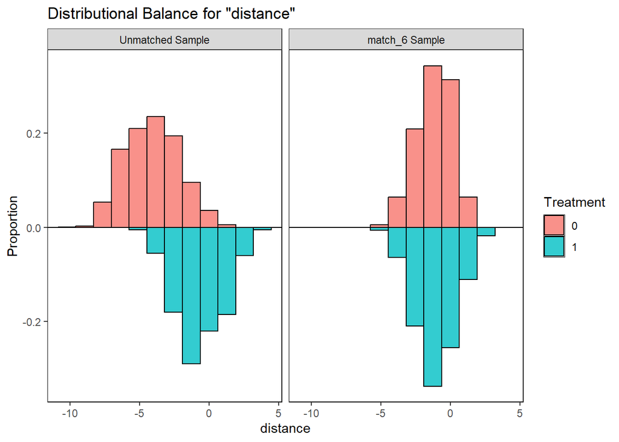

```r
bal.plot(match_6,
         var.name = "distance",
         which = "both",
         sample.names =
             c("Unmatched Sample", "match_6 Sample"),
         type = "histogram", mirror = TRUE)
```

### 8.2.4 Using `love.plot` to look at Standardized Differences

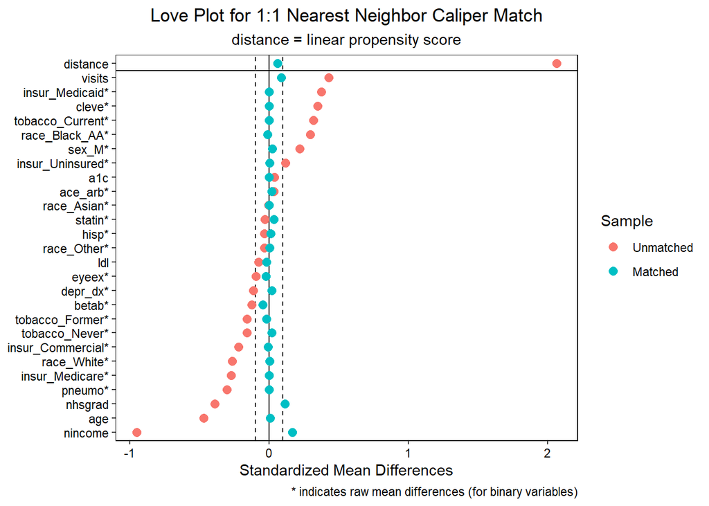

```r
love.plot(bal6,
          threshold = .1, size = 3,
          var.order = "unadjusted",
          stats = "mean.diffs",
          stars = "raw",
          sample.names = c("Unmatched", "Matched"),
          title = "Love Plot for 1:1 Nearest Neighbor Caliper Match") +
    labs(subtitle = "distance = linear propensity score",
         caption = "* indicates raw mean differences (for binary variables)")
```

### 8.2.5 Using `love.plot` to look at Variance Ratios

Again, the categorical variables are dropped.

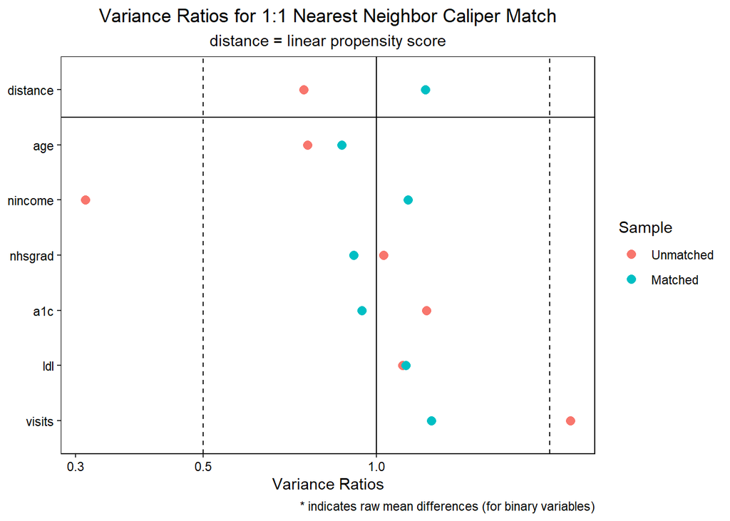

```r
love.plot(bal6,
          threshold = .5, size = 3,
          stats = "variance.ratios",
          sample.names = c("Unmatched", "Matched"),
          title = "Variance Ratios for 1:1 Nearest Neighbor Caliper Match") +
    labs(subtitle = "distance = linear propensity score",
         caption = "* indicates raw mean differences (for binary variables)")
```

# 9 `match_7` 1:1 Optimal Matching with `Matchit`

As in `match_5`, we’ll match on the linear propensity score (by specifying the `distance` to use the logistic link with the linear propensity score via `"linear.logit"`), but now we’ll use an optimal 1:1 matching (which is always done in `matchit` without replacement).

```r
match_7 <- matchit(f.build("treat", covs_1), data = dm2200,
                   distance = "glm", link = "linear.logit",
                   method = "optimal", ratio = 1)

match_7
```

```
A `matchit` object
 - method: 1:1 optimal pair matching
 - distance: Propensity score
             - estimated with logistic regression and linearized
 - number of obs.: 2200 (original), 400 (matched)
 - target estimand: ATT
 - covariates: age, race, hisp, sex, insur, nincome, nhsgrad, cleve, a1c, ldl, visits, tobacco, statin, ace_arb, betab, depr_dx, eyeex, pneumo
```

## 9.1 Obtaining the Matched Sample

As before, much of the work can be done with `match.data`.

```r
dm2200_matched7 <- match.data(match_7)
```

This leaves only the job of creating a matching number, for which we have to develop some additional R code.

```r
# Thanks to Robert McDonald at Mayo
# https://lists.gking.harvard.edu/pipermail/matchit/2012-April/000458.html

len <- dim(dm2200)[1]
matchx <- rep(NA,len)
len2 <- length(match_7$match.matrix)
count <- 1
for(i in 1:len2){

    match1 <- match_7$match.matrix[i]
    match2 <- row.names(match_7$match.matrix)[i]

    if(!is.na(match1)){
    matchx[as.numeric(match1)] <- count
    matchx[as.numeric(match2)] <- count
    count <- count+1}

}

dm2200_matched7 <- dm2200_matched7 |>
    mutate(match7_matches =
               matchx[as.numeric
                      (row.names(dm2200_matched7))]) |>
    mutate(match7_matches = factor(match7_matches))
```

How many unique subjects are in our matched sample?

```r
n_distinct(dm2200_matched7$subject)
```

```
[1] 400
```

This match includes 200 pairs so 400 subjects, as we’ve done matching without replacement.

```r
dm2200_matched7 |> count(exposure)
```

```
# A tibble: 2 × 2
  exposure     n
  <fct>    <int>
1 A          200
2 B          200
```

## 9.2 Checking Covariate Balance for our 1:1 Optimal Match

### 9.2.1 Using `bal.tab` to obtain a balance table

```r
bal7 <- bal.tab(match_7, un = TRUE, disp.v.ratio = TRUE)

bal7
```

```
Balance Measures
                     Type Diff.Un V.Ratio.Un Diff.Adj V.Ratio.Adj
distance         Distance  2.0650     0.7466   0.2460      1.8591
age               Contin. -0.4682     0.7579   0.1005      0.8433
race_Black_AA      Binary  0.2975          .   0.0050           .
race_White         Binary -0.2630          .  -0.0050           .
race_Other         Binary -0.0320          .   0.0000           .
race_Asian         Binary -0.0025          .   0.0000           .
hisp               Binary -0.0320          .   0.0000           .
sex_M              Binary  0.2190          .   0.0400           .
insur_Medicare     Binary -0.2715          .   0.0100           .
insur_Commercial   Binary -0.2200          .   0.0050           .
insur_Medicaid     Binary  0.3745          .  -0.0200           .
insur_Uninsured    Binary  0.1170          .   0.0050           .
nincome           Contin. -0.9504     0.3117   0.1197      1.0425
nhsgrad           Contin. -0.3904     1.0281  -0.0226      1.1902
cleve              Binary  0.3505          .   0.0050           .
a1c               Contin.  0.0379     1.2209   0.0135      0.9199
ldl               Contin. -0.0743     1.1096  -0.0443      1.0515
visits            Contin.  0.4276     2.1732   0.1754      1.2822
tobacco_Former     Binary -0.1575          .  -0.0350           .
tobacco_Current    Binary  0.3175          .   0.0400           .
tobacco_Never      Binary -0.1600          .  -0.0050           .
statin             Binary -0.0315          .   0.0500           .
ace_arb            Binary  0.0345          .   0.0500           .
betab              Binary -0.1255          .  -0.0600           .
depr_dx            Binary -0.1115          .  -0.0450           .
eyeex              Binary -0.0925          .  -0.0050           .
pneumo             Binary -0.3030          .  -0.0800           .

Sample sizes
          Control Treated
All          2000     200
Matched       200     200
Unmatched    1800       0
```

### 9.2.2 Checking Rubin’s Rules 1 and 2

```r
rubin_report_m567 <- tibble(
    status = c("Rule1", "Rule2"),
    Unmatched = c(bal6$Balance$Diff.Un[1],
                  bal6$Balance$V.Ratio.Un[1]),
    Match5 = c(bal5$Balance$Diff.Adj[1],
               bal5$Balance$V.Ratio.Adj[1]),
    Match6 = c(bal6$Balance$Diff.Adj[1],
               bal6$Balance$V.Ratio.Adj[1]),
    Match7 = c(bal7$Balance$Diff.Adj[1],
               bal7$Balance$V.Ratio.Adj[1])
    )

rubin_report_m567 |> gt() |> fmt_number(decimals = 3) |>
  opt_stylize(style = 2, color = "blue")
```

| status | Unmatched | Match5 | Match6 | Match7 |
| --- | --- | --- | --- | --- |
| Rule1 | 2.065 | 0.246 | 0.061 | 0.246 |
| Rule2 | 0.747 | 1.859 | 1.215 | 1.859 |

- We note here that the optimal matching here does very little, if anything, to improved on the nearest neighbor match.

### 9.2.3 Are the Optimal and Nearest Neighbor Matches the Same?

```r
m5_subs <- dm2200_matched5 |> select(subject)
m7_subs <- dm2200_matched7 |> select(subject)

all.equal(m5_subs, m7_subs)
```

```
[1] "Component \"subject\": 356 string mismatches"
```

### 9.2.4 Using `bal.plot` from `cobalt`

Looking at the linear propensity scores in each group, in mirrored histograms, we have …

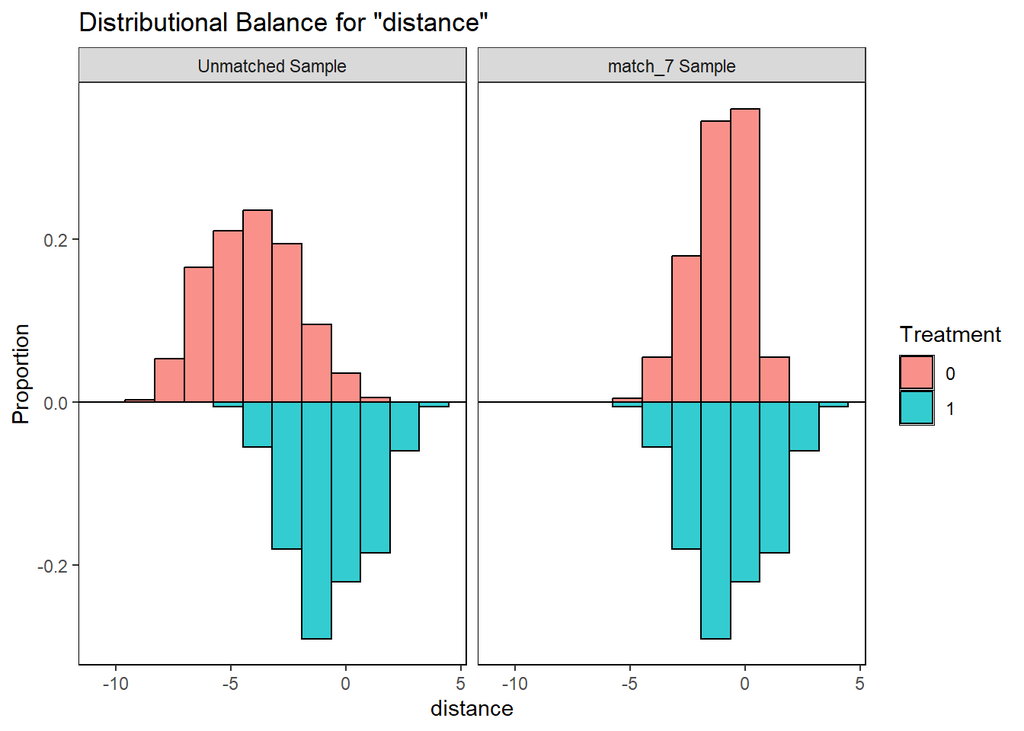

```r
bal.plot(match_7,
         var.name = "distance",
         which = "both",
         sample.names =
             c("Unmatched Sample", "match_7 Sample"),
         type = "histogram", mirror = TRUE)
```

### 9.2.5 Using `love.plot` to look at Standardized Differences

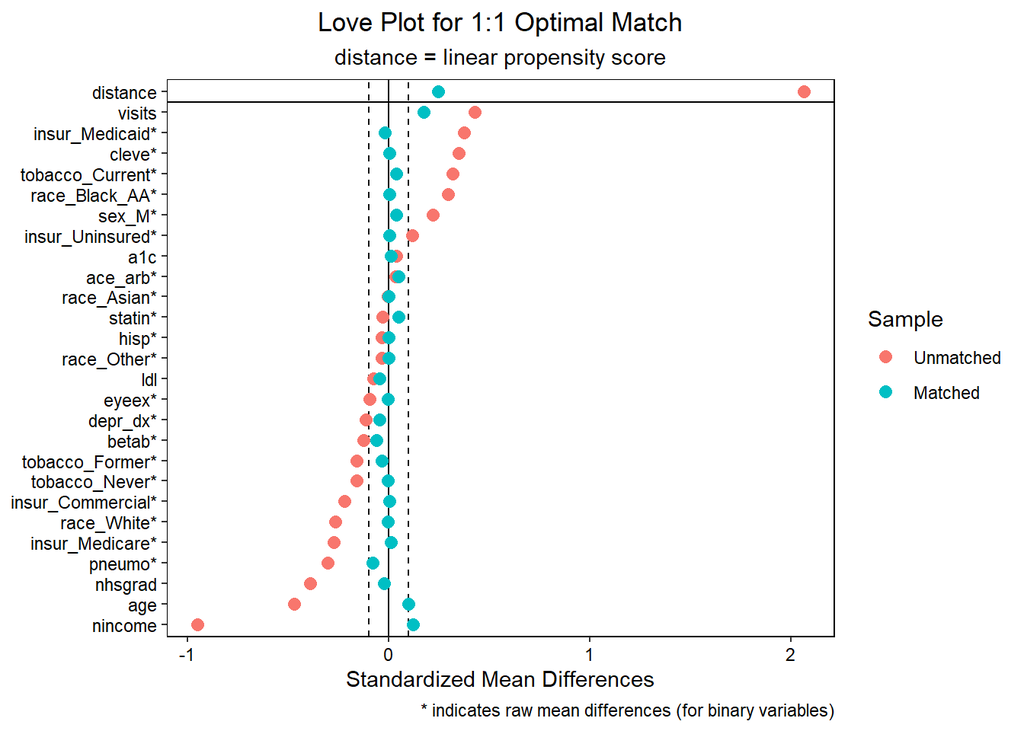

```r
love.plot(bal7,
          threshold = .1, size = 3,
          var.order = "unadjusted",
          stats = "mean.diffs",
          stars = "raw",
          sample.names = c("Unmatched", "Matched"),
          title = "Love Plot for 1:1 Optimal Match") +
    labs(subtitle = "distance = linear propensity score",
         caption = "* indicates raw mean differences (for binary variables)")
```

### 9.2.6 Using `love.plot` to look at Variance Ratios

Again, the categorical variables are dropped.

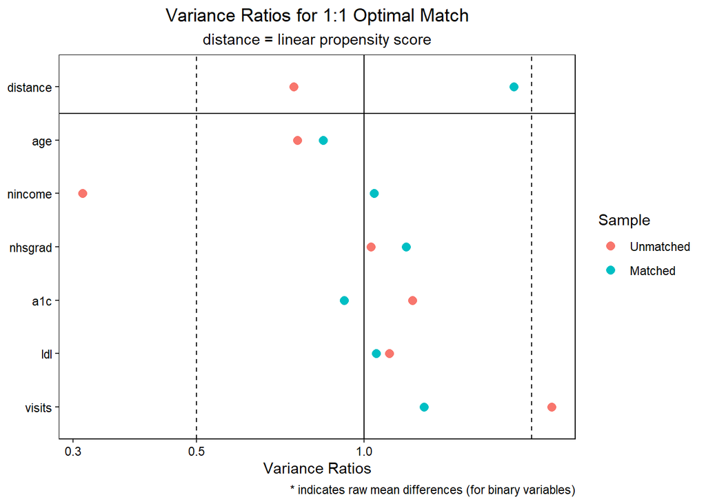

```r
love.plot(bal7,
          threshold = .5, size = 3,
          stats = "variance.ratios",
          sample.names = c("Unmatched", "Matched"),
          title = "Variance Ratios for 1:1 Optimal Match") +
    labs(subtitle = "distance = linear propensity score",
         caption = "* indicates raw mean differences (for binary variables)")
```

# 10 `match_8` 1:2 Optimal Matching with `Matchit`

Again, we’ll match on the linear propensity score (by specifying the `distance` to use the logistic link with the linear propensity score via `"linear.logit"`), but now we’ll perform 1:2 (so `ratio = 2`) optimal (so `method = “optimal”) matching without replacement using the default ordering (largest to smallest).

```r
match_8 <- matchit(f.build("treat", covs_1), data = dm2200,
                   distance = "glm", link = "linear.logit",
                   method = "optimal", ratio = 2)

match_8
```

```
A `matchit` object
 - method: 2:1 optimal pair matching
 - distance: Propensity score
             - estimated with logistic regression and linearized
 - number of obs.: 2200 (original), 600 (matched)
 - target estimand: ATT
 - covariates: age, race, hisp, sex, insur, nincome, nhsgrad, cleve, a1c, ldl, visits, tobacco, statin, ace_arb, betab, depr_dx, eyeex, pneumo
```

## 10.1 Obtaining the Matched Sample

As before, much of the work can be done with a very simple command.

```r
dm2200_matched8 <- match.data(match_8)
```

This leaves only the job of creating a matching number, for which we have to develop some additional R code, and this needs some modification because we now have two matched controls for each treated subject.

```r
# Thanks to Robert McDonald at Mayo
# https://lists.gking.harvard.edu/pipermail/matchit/2012-April/000458.html

mm1 <- match_8$match.matrix[,1]
mm2 <- match_8$match.matrix[,2]

len <- dim(dm2200)[1]
matchx <- rep(NA,len)
len2 <- length(match_8$match.matrix)
count <- 1
for(i in 1:len2){

    match_tr <- row.names(match_8$match.matrix)[i]
    match_con1 <- mm1[i]
    match_con2 <- mm2[i]

    if(!is.na(match_tr) & !is.na(match_con1) & !is.na(match_con2)){
    matchx[as.numeric(match_con1)] <- count
    matchx[as.numeric(match_con2)] <- count
    matchx[as.numeric(match_tr)] <- count
    count <- count+1}

}

dm2200_matched8 <- dm2200_matched8 |>
     mutate(match8_matches =
            matchx[as.numeric(row.names(dm2200_matched8))])
```

How many unique subjects are in our matched sample?

```r
n_distinct(dm2200_matched8$subject)
```

```
[1] 600
```

This match includes 200 triplets (1 treated and 2 control) so 600 subjects, and again we’ve done matching without replacement.

```r
dm2200_matched8 |> count(exposure)
```

```
# A tibble: 2 × 2
  exposure     n
  <fct>    <int>
1 A          200
2 B          400
```

## 10.2 Checking Covariate Balance for our 1:2 Optimal Match

### 10.2.1 Using `bal.tab` to obtain a balance table

```r
bal8 <- bal.tab(match_8, un = TRUE, disp.v.ratio = TRUE)

bal8
```

```
Balance Measures
                     Type Diff.Un V.Ratio.Un Diff.Adj V.Ratio.Adj
distance         Distance  2.0650     0.7466   0.5002      2.4424
age               Contin. -0.4682     0.7579  -0.0605      0.8144
race_Black_AA      Binary  0.2975          .   0.0225           .
race_White         Binary -0.2630          .  -0.0225           .
race_Other         Binary -0.0320          .   0.0000           .
race_Asian         Binary -0.0025          .   0.0000           .
hisp               Binary -0.0320          .  -0.0050           .
sex_M              Binary  0.2190          .   0.0700           .
insur_Medicare     Binary -0.2715          .  -0.0800           .
insur_Commercial   Binary -0.2200          .  -0.0025           .
insur_Medicaid     Binary  0.3745          .   0.0350           .
insur_Uninsured    Binary  0.1170          .   0.0475           .
nincome           Contin. -0.9504     0.3117   0.0429      0.7310
nhsgrad           Contin. -0.3904     1.0281  -0.0139      0.9187
cleve              Binary  0.3505          .   0.0175           .
a1c               Contin.  0.0379     1.2209   0.0463      1.1943
ldl               Contin. -0.0743     1.1096  -0.0223      1.0845
visits            Contin.  0.4276     2.1732   0.2097      1.3355
tobacco_Former     Binary -0.1575          .  -0.0550           .
tobacco_Current    Binary  0.3175          .   0.1075           .
tobacco_Never      Binary -0.1600          .  -0.0525           .
statin             Binary -0.0315          .  -0.0025           .
ace_arb            Binary  0.0345          .   0.0075           .
betab              Binary -0.1255          .  -0.0375           .
depr_dx            Binary -0.1115          .  -0.0600           .
eyeex              Binary -0.0925          .  -0.0225           .
pneumo             Binary -0.3030          .  -0.1475           .

Sample sizes
          Control Treated
All          2000     200
Matched       400     200
Unmatched    1600       0
```

### 10.2.2 Checking Rubin’s Rules 1 and 2

We’ll build a little table of the Rubin’s Rules (1 and 2) results before and after `match_8` is applied, and compare these to the other `MatchIt` results we’ve developed.

```r
rubin_report_m5678 <- tibble(
    status = c("Rule1", "Rule2"),
    Unmatched = c(bal8$Balance$Diff.Un[1],
                  bal8$Balance$V.Ratio.Un[1]),
    Match5 = c(bal5$Balance$Diff.Adj[1],
               bal5$Balance$V.Ratio.Adj[1]),
    Match6 = c(bal6$Balance$Diff.Adj[1],
               bal6$Balance$V.Ratio.Adj[1]),
    Match7 = c(bal7$Balance$Diff.Adj[1],
               bal7$Balance$V.Ratio.Adj[1]),
    Match8 = c(bal8$Balance$Diff.Adj[1],
               bal8$Balance$V.Ratio.Adj[1])
    )

rubin_report_m5678 |> gt() |> fmt_number(decimals = 3) |>
  opt_stylize(style = 2, color = "blue")
```

| status | Unmatched | Match5 | Match6 | Match7 | Match8 |
| --- | --- | --- | --- | --- | --- |
| Rule1 | 2.065 | 0.246 | 0.061 | 0.246 | 0.500 |
| Rule2 | 0.747 | 1.859 | 1.215 | 1.859 | 2.442 |

- So the optimal matching doesn’t look very strong here. Of course, we’re matching 1:2 in this situation.

### 10.2.3 Using `bal.plot` from `cobalt`

Looking at the linear propensity scores in each group, in mirrored histograms, we have …

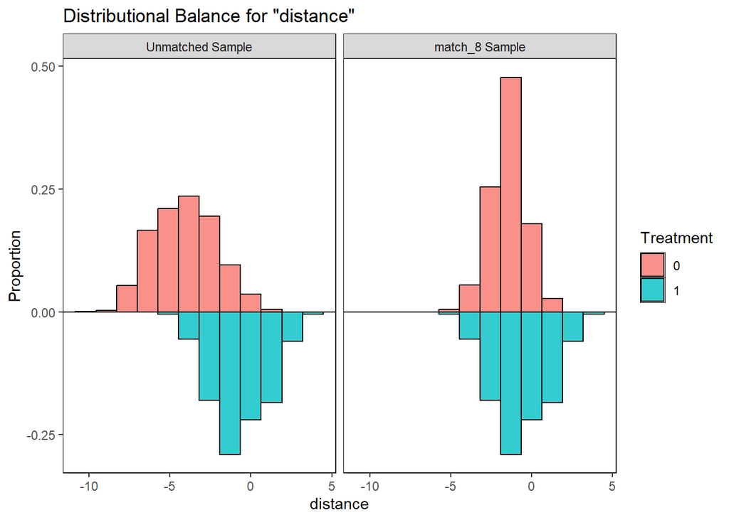

```r
bal.plot(match_8,
         var.name = "distance",
         which = "both",
         sample.names =
             c("Unmatched Sample", "match_8 Sample"),
         type = "histogram", mirror = TRUE)
```

### 10.2.4 Using `love.plot` to look at Standardized Differences

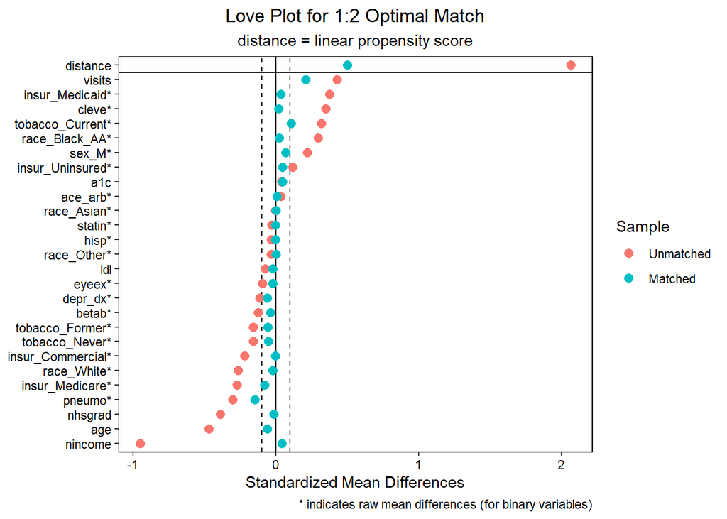

```r
love.plot(bal8,
          threshold = .1, size = 3,
          var.order = "unadjusted",
          stats = "mean.diffs",
          stars = "raw",
          sample.names = c("Unmatched", "Matched"),
          title = "Love Plot for 1:2 Optimal Match") +
    labs(subtitle = "distance = linear propensity score",
         caption = "* indicates raw mean differences (for binary variables)")
```

### 10.2.5 Using `love.plot` to look at Variance Ratios

Again, the categorical variables are dropped.

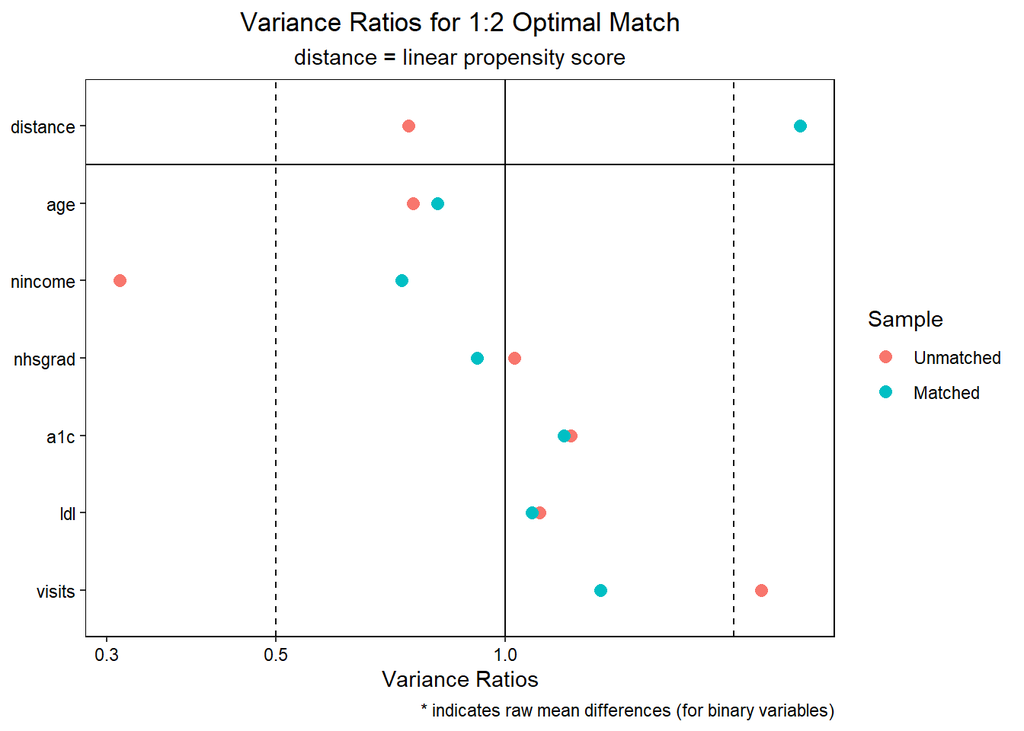

```r
love.plot(bal8,
          threshold = .5, size = 3,
          stats = "variance.ratios",
          sample.names = c("Unmatched", "Matched"),
          title = "Variance Ratios for 1:2 Optimal Match") +
    labs(subtitle = "distance = linear propensity score",
         caption = "* indicates raw mean differences (for binary variables)")
```

# 11 Outcome Models

We’ll fit two (overly simplistic) outcome models, one for `bp_good` (our binary outcome) and another for `bmi` (our quantitative outcome.) Later, we’ll compare the `exposure` effect estimates made here to the estimates we obtain after propensity matching. In each case, we’ll focus on ATT estimates (average treated effect on the treated) rather than ATE estimates.

## 11.1 Potential Fitting Problems

When you fit mixed effect models as I have done below for binary and for quantitative outcomes, you may find that the model fit appears to be singular, which means that some element of the variance-covariance matrix estimated by `lmer` is zero. This may be an ignorable problem in this setting, since the problem is usually with the separation of residual effects from random match effects. We’re focusing right now on the fixed effects, which can be summarized as indicated below.

But, there’s certainly an argument to be made that an alternative strategy for estimating the match might be more appropriate. We won’t worry about that in this example, and just display what we get.

## 11.2 Unadjusted Models prior to Propensity Matching

### 11.2.1 Unadjusted Outcome Model for `bp_good`

```r
unadj_mod1 <- glm(bp_good == 1 ~ exposure == "A", data = dm2200,
                  family = binomial())

tidy(unadj_mod1, exponentiate = TRUE, conf.int = TRUE, conf.level = 0.95) |>
    select(term, estimate, std.error, conf.low, conf.high) |>
    gt() |> fmt_number(decimals = 3) |>
  opt_stylize(style = 4, color = "blue")
```

| term | estimate | std.error | conf.low | conf.high |
| --- | --- | --- | --- | --- |
| (Intercept) | 2.515 | 0.050 | 2.284 | 2.773 |
| exposure == "A"TRUE | 0.561 | 0.152 | 0.417 | 0.757 |

### 11.2.2 Unadjusted Outcome Model for `bmi`

```r
unadj_mod2 <- lm(bmi ~ exposure == "A", data = dm2200)

tidy(unadj_mod2, conf.int = TRUE, conf.level = 0.95) |>
    select(term, estimate, std.error,
           conf.low, conf.high) |>
    gt() |> fmt_number(decimals = 3) |>
  opt_stylize(style = 4, color = "blue")
```

| term | estimate | std.error | conf.low | conf.high |
| --- | --- | --- | --- | --- |
| (Intercept) | 35.087 | 0.183 | 34.729 | 35.446 |
| exposure == "A"TRUE | −2.260 | 0.606 | −3.449 | −1.071 |

## 11.3 Adjusted Outcome Models after `match1`

### 11.3.1 Binary Outcome: `bp_good`

```r
result_match1_bp <- clogit(bp_good ~ (exposure == "A") +
                          strata(match1_matches),
                      data = dm2200_matched1)

tidy(result_match1_bp, exponentiate = TRUE, conf.int = TRUE, conf.level = 0.95) |>
    select(term, estimate, std.error, conf.low, conf.high) |>
    gt() |> fmt_number(decimals = 3) |>
  opt_stylize(style = 4, color = "blue")
```

| term | estimate | std.error | conf.low | conf.high |
| --- | --- | --- | --- | --- |
| exposure == "A"TRUE | 0.559 | 0.217 | 0.365 | 0.856 |

### 11.3.2 Quantitative Outcome: `bmi`

We’ll use a mixed model to account for our 1:1 matching. The matches here are treated as a random factor, with the exposure a fixed factor, in the `lme4` package.

```r
dm2200_matched1 <- dm2200_matched1 |>
    mutate(match1_matches_f = as.factor(match1_matches))

result_match1_bmi <- lmer(bmi ~ (exposure == "A") +
                              (1 | match1_matches_f),
                          data = dm2200_matched1)
```

```r
broom.mixed::tidy(result_match1_bmi,
     conf.int = TRUE, conf.level = 0.95) |>
    filter(effect == "fixed") |>
    select(term, estimate, std.error,
           conf.low, conf.high) |>
    gt() |> fmt_number(decimals = 3) |>
  opt_stylize(style = 4, color = "blue")
```

| term | estimate | std.error | conf.low | conf.high |
| --- | --- | --- | --- | --- |
| (Intercept) | 35.168 | 0.612 | 33.969 | 36.367 |
| exposure == "A"TRUE | −2.341 | 0.857 | −4.020 | −0.662 |

## 11.4 Adjusted Outcome Models after `match2`

### 11.4.1 Binary Outcome: `bp_good`

```r
result_match2_bp <- clogit(bp_good ~ (exposure == "A") +
                          strata(match2_matches),
                      data = dm2200_matched2)

tidy(result_match2_bp, exponentiate = TRUE, conf.int = TRUE, conf.level = 0.95) |>
    select(term, estimate, std.error, conf.low, conf.high) |>
    gt() |> fmt_number(decimals = 3) |>
  opt_stylize(style = 4, color = "blue")
```

| term | estimate | std.error | conf.low | conf.high |
| --- | --- | --- | --- | --- |
| exposure == "A"TRUE | 0.417 | 0.180 | 0.293 | 0.593 |

### 11.4.2 Quantitative Outcome: `bmi`

We’ll use a mixed model to account for our 1:1 matching. The matches here are treated as a random factor, with the exposure a fixed factor, in the `lme4` package.

```r
dm2200_matched2 <- dm2200_matched2 |>
    mutate(match2_matches_f = as.factor(match2_matches))

result_match2_bmi <- lmer(bmi ~ (exposure == "A") +
                              (1 | match2_matches_f),
                          data = dm2200_matched2)

broom.mixed::tidy(result_match2_bmi,
     conf.int = TRUE, conf.level = 0.95) |>
    filter(effect == "fixed") |>
    select(term, estimate, std.error, conf.low, conf.high) |>
    gt() |> fmt_number(decimals = 3) |>
  opt_stylize(style = 4, color = "blue")
```

| term | estimate | std.error | conf.low | conf.high |
| --- | --- | --- | --- | --- |
| (Intercept) | 34.609 | 0.458 | 33.712 | 35.506 |
| exposure == "A"TRUE | −1.782 | 0.558 | −2.876 | −0.688 |

## 11.5 Adjusted Outcome Models after `match3`

### 11.5.1 Binary Outcome: `bp_good`

```r
result_match3_bp <- clogit(bp_good ~ (exposure == "A") +
                          strata(match3_matches),
                      data = dm2200_matched3)

tidy(result_match3_bp, exponentiate = TRUE, conf.int = TRUE, conf.level = 0.95) |>
    select(term, estimate, std.error, conf.low, conf.high) |>
    gt() |> fmt_number(decimals = 3) |>
  opt_stylize(style = 4, color = "blue")
```

| term | estimate | std.error | conf.low | conf.high |
| --- | --- | --- | --- | --- |
| exposure == "A"TRUE | 0.573 | 0.139 | 0.436 | 0.753 |

### 11.5.2 Quantitative Outcome: `bmi`

We’ll use a mixed model to account for our 1:1 matching. The matches here are treated as a random factor, with the exposure a fixed factor, in the `lme4` package.

```r
dm2200_matched3 <- dm2200_matched3 |>
    mutate(match3_matches_f = as.factor(match3_matches))

result_match3_bmi <- lmer(bmi ~ (exposure == "A") +
                              (1 | match3_matches_f),
                          data = dm2200_matched3)

broom.mixed::tidy(result_match3_bmi,
     conf.int = TRUE, conf.level = 0.95) |>
    filter(effect == "fixed") |>
    select(term, estimate, std.error,
           conf.low, conf.high) |>
    gt() |> fmt_number(decimals = 3) |>
  opt_stylize(style = 4, color = "blue")
```

| term | estimate | std.error | conf.low | conf.high |
| --- | --- | --- | --- | --- |
| (Intercept) | 34.531 | 0.410 | 33.728 | 35.335 |
| exposure == "A"TRUE | −1.704 | 0.449 | −2.584 | −0.824 |

## 11.6 Adjusted Outcome Models after `match4`

### 11.6.1 Binary Outcome: `bp_good`

```r
result_match4_bp <- clogit(bp_good ~ (exposure == "A") +
                          strata(match4_matches),
                      data = dm2200_matched4)

tidy(result_match4_bp, exponentiate = TRUE, conf.int = TRUE, conf.level = 0.95) |>
    select(term, estimate, std.error, conf.low, conf.high) |>
    gt() |> fmt_number(decimals = 3) |>
  opt_stylize(style = 4, color = "blue")
```

| term | estimate | std.error | conf.low | conf.high |
| --- | --- | --- | --- | --- |
| exposure == "A"TRUE | 0.651 | 0.243 | 0.405 | 1.048 |

### 11.6.2 Quantitative Outcome: `bmi`

We’ll use a mixed model to account for our 1:1 matching. The matches here are treated as a random factor, with the exposure a fixed factor, in the `lme4` package.

```r
dm2200_matched4 <- dm2200_matched4 |>
    mutate(match4_matches_f = as.factor(match4_matches))

result_match4_bmi <- lmer(bmi ~ (exposure == "A") +
                              (1 | match4_matches_f),
                          data = dm2200_matched4)
```

```
boundary (singular) fit: see help('isSingular')
```

```r
broom.mixed::tidy(result_match4_bmi,
     conf.int = TRUE, conf.level = 0.95) |>
    filter(effect == "fixed") |>
    select(term, estimate, std.error, conf.low, conf.high) |>
    gt() |> fmt_number(decimals = 3) |>
  opt_stylize(style = 4, color = "blue")
```

| term | estimate | std.error | conf.low | conf.high |
| --- | --- | --- | --- | --- |
| (Intercept) | 34.828 | 0.657 | 33.540 | 36.116 |
| exposure == "A"TRUE | −1.577 | 0.929 | −3.399 | 0.244 |

## 11.7 Adjusted Outcome Models after `match5`

### 11.7.1 Binary Outcome: `bp_good`

```r
result_match5_bp <- clogit(bp_good ~ (exposure == "A") +
                          strata(match5_matches),
                      data = dm2200_matched5)
tidy(result_match5_bp, exponentiate = TRUE,
     conf.int = TRUE, conf.level = 0.95) |>
    select(term, estimate, std.error, conf.low, conf.high) |>
    gt() |> fmt_number(decimals = 3) |>
  opt_stylize(style = 4, color = "blue")
```

| term | estimate | std.error | conf.low | conf.high |
| --- | --- | --- | --- | --- |
| exposure == "A"TRUE | 1,615,474,899.108 | 40,192.969 | 0.000 | Inf |

### 11.7.2 Quantitative Outcome: `bmi`

We’ll use a mixed model to account for our 1:1 matching. The matches here are treated as a random factor, with the exposure a fixed factor, in the `lme4` package.

```r
result_match5_bmi <- lmer(bmi ~ (exposure == "A") +
                              (1 | match5_matches),
                          data = dm2200_matched5)
```

```
boundary (singular) fit: see help('isSingular')
```

```r
broom.mixed::tidy(result_match5_bmi,
     conf.int = TRUE, conf.level = 0.95) |>
    filter(effect == "fixed") |>
    select(term, estimate, std.error,
           conf.low, conf.high) |>
    gt() |> fmt_number(decimals = 3) |>
  opt_stylize(style = 4, color = "blue")
```

| term | estimate | std.error | conf.low | conf.high |
| --- | --- | --- | --- | --- |
| (Intercept) | 33.258 | 1.354 | 30.605 | 35.911 |
| exposure == "A"TRUE | 1.683 | 2.037 | −2.310 | 5.676 |

## 11.8 Adjusted Outcome Models after `match6`

### 11.8.1 Binary Outcome: `bp_good`

```r
result_match6_bp <- clogit(bp_good ~ (exposure == "A") +
                          strata(match6_matches),
                      data = dm2200_matched6)
tidy(result_match6_bp, exponentiate = TRUE,
     conf.int = TRUE, conf.level = 0.95) |>
    select(term, estimate, std.error, conf.low, conf.high) |>
    gt() |> fmt_number(decimals = 3) |>
  opt_stylize(style = 4, color = "blue")
```

| term | estimate | std.error | conf.low | conf.high |
| --- | --- | --- | --- | --- |
| exposure == "A"TRUE | 0.000 | 24,378.269 | 0.000 | Inf |

### 11.8.2 Quantitative Outcome: `bmi`

We’ll use a mixed model to account for our 1:1 matching. The matches here are treated as a random factor, with the exposure a fixed factor, in the `lme4` package.

```r
result_match6_bmi <- lmer(bmi ~ (exposure == "A") +
                              (1 | match6_matches),
                          data = dm2200_matched6)
```

```
boundary (singular) fit: see help('isSingular')
```

```r
broom.mixed::tidy(result_match6_bmi,
     conf.int = TRUE, conf.level = 0.95) |>
    filter(effect == "fixed") |>
    select(term, estimate, std.error, conf.low, conf.high) |>
    gt() |> fmt_number(decimals = 3) |>
  opt_stylize(style = 4, color = "blue")
```

| term | estimate | std.error | conf.low | conf.high |
| --- | --- | --- | --- | --- |
| (Intercept) | 34.338 | 1.982 | 30.453 | 38.223 |
| exposure == "A"TRUE | 1.097 | 2.567 | −3.934 | 6.129 |

## 11.9 Adjusted Outcome Models after `match7`

### 11.9.1 Binary Outcome: `bp_good`

```r
result_match7_bp <- clogit(bp_good ~ (exposure == "A") +
                          strata(match7_matches),
                      data = dm2200_matched7)

tidy(result_match7_bp, exponentiate = TRUE,
     conf.int = TRUE, conf.level = 0.95) |>
    select(term, estimate, std.error, conf.low, conf.high) |>
    gt() |> fmt_number(decimals = 3) |>
  opt_stylize(style = 4, color = "blue")
```

| term | estimate | std.error | conf.low | conf.high |
| --- | --- | --- | --- | --- |
| exposure == "A"TRUE | 2.000 | 1.225 | 0.181 | 22.056 |

### 11.9.2 Quantitative Outcome: `bmi`

We’ll use a mixed model to account for our 1:1 matching. The matches here are treated as a random factor, with the exposure a fixed factor, in the `lme4` package.

```r
result_match7_bmi <- lmer(bmi ~ (exposure == "A") +
                              (1 | match7_matches),
                          data = dm2200_matched7)

broom.mixed::tidy(result_match7_bmi,
     conf.int = TRUE, conf.level = 0.95) |>
    filter(effect == "fixed") |>
    select(term, estimate, std.error,
           conf.low, conf.high) |>
    gt() |> fmt_number(decimals = 3) |>
  opt_stylize(style = 4, color = "blue")
```

| term | estimate | std.error | conf.low | conf.high |
| --- | --- | --- | --- | --- |
| (Intercept) | 35.658 | 1.416 | 32.882 | 38.433 |
| exposure == "A"TRUE | −3.210 | 1.884 | −6.903 | 0.484 |

## 11.10 Adjusted Outcome Models after `match8`

### 11.10.1 Binary Outcome: `bp_good`

```r
result_match8_bp <- clogit(bp_good ~ (exposure == "A") +
                          strata(match8_matches),
                      data = dm2200_matched8)

tidy(result_match8_bp, exponentiate = TRUE,
     conf.int = TRUE, conf.level = 0.95) |>
    select(term, estimate, std.error, conf.low, conf.high) |>
    gt() |> fmt_number(decimals = 3) |>
  opt_stylize(style = 4, color = "blue")
```

| term | estimate | std.error | conf.low | conf.high |
| --- | --- | --- | --- | --- |
| exposure == "A"TRUE | 1.073 | 0.650 | 0.300 | 3.839 |

### 11.10.2 Quantitative Outcome: `bmi`

```r
dm2200_matched8 <- dm2200_matched8 |>
    mutate(match8_f = factor(match8_matches))

result_match8_bmi <- lmer(bmi ~ (exposure == "A") +
                              (1 | match8_f),
                          data = dm2200_matched8)

broom.mixed::tidy(result_match8_bmi,
     conf.int = TRUE, conf.level = 0.95) |>
    filter(effect == "fixed") |>
    select(term, estimate, std.error,
           conf.low, conf.high) |>
    gt() |> fmt_number(decimals = 3) |>
  opt_stylize(style = 4, color = "blue")
```

| term | estimate | std.error | conf.low | conf.high |
| --- | --- | --- | --- | --- |
| (Intercept) | 34.597 | 0.786 | 33.057 | 36.137 |
| exposure == "A"TRUE | −3.797 | 1.329 | −6.402 | −1.192 |

# 12 Cleanup

We’ve created a lot of variables here that we don’t actually need going forward. So I’ll remove them here:

```r
rm(bal1, bal2, bal3, bal4,
   covs_1, covs_1plus, covs_2plus, covs_3plus, covs_4plus,
   covs_for_rubin, dm2200,
   dm2200_matched1, dm2200_matched2, dm2200_matched3,
   dm2200_matched4,
   match_1, match_2, match_3, match_4,
   prop_model,
   result_match1_bmi, result_match2_bmi, result_match3_bmi,
   result_match4_bmi,
   result_match1_bp, result_match2_bp, result_match3_bp,
   result_match4_bp,
   rubin_m1, rubin_m2, rubin_m3, rubin_m4,
   rubin_report_m1, rubin_report_m12, rubin_report_m123,
   rubin_report_m1234, rubin_report_m5,
   rubin_report_m56, rubin_report_m567, rubin_report_m5678,
   t1, unadj_mod1, unadj_mod2,
   match1_matches, match2_matches, match3_matches,
   count, i, len, len2, match_con1, match_con2, match_tr,
   match1, match2, match4_matches, matchx, mm1, mm2,
   bal5, bal6, bal7, bal8, dm2200_matched5,
   dm2200_matched6, dm2200_matched7, dm2200_matched8,
   m5_subs, m7_subs, match_5, match_6, match_7, match_8,
   result_match5_bmi, result_match6_bmi, result_match7_bmi,
   result_match8_bmi,
   result_match5_bp, result_match6_bp, result_match7_bp,
   result_match8_bp)
```

# 13 Key References

Matching in these examples was performed using the Matching package (Sekhon, 2011), and the MatchIt package and covariate balance was assessed using cobalt (Greifer, 2020), both in R (R Core Team, 2019).

- Greifer, N. (2020). cobalt: Covariate Balance Tables and Plots. R package version 4.3.0.
- [MatchIt](https://kosukeimai.github.io/MatchIt/): Nonparametric Preprocessing for Parametric Causal Inference, R package version 4.1.0.
  - See also [MatchIt: Getting Started](https://cran.r-project.org/web/packages/MatchIt/vignettes/MatchIt.html) by Noah Greifer.
- Sekhon, J.S. (2011) Multivariate and Propensity Score Matching Software with Automated Balance Optimization: The Matching Package for R, *J of Statistical Software*, 2011, 42: 7, http://www.jstatsoft.org/. R package version 4.9-6.
- R Core Team (2019). R: A language and environment for statistical computing. R Foundation for Statistical Computing, Vienna, Austria. URL https://www.R-project.org/.